# CAPSTONE PROJECT (Real Estate Case Study)

# Data Pre-processing:

# Project Task: Week 3

# 1. The economic multivariate data has a significant number of measured variables. The goal is to find where the measured variables depend on a number of smaller unobserved common factors or latent variables. Each variable is assumed to be dependent upon a linear combination of the common factors, and the coefficients are known as loadings. Each measured variable also includes a component due to independent random variability, known as “specific variance” because it is specific to one variable. Obtain the common factors and then plot the loadings. Use factor analysis to find latent variables in our dataset and gain insight into the linear relationships in the data. Following are the list of latent variables: • Highschool graduation rates • Median population age • Second mortgage statistics • Percent own • Bad debt expense </h1>

```python
train_df.info()
```

```
<class 'pandas.core.frame.DataFrame'>
Int64Index: 26585 entries, 0 to 27320
Data columns (total 78 columns):
 #   Column                       Non-Null Count  Dtype
---  ------                       --------------  -----
 0   UID                          26585 non-null  category
 1   SUMLEVEL                     26585 non-null  int64
 2   COUNTYID                     26585 non-null  category
 3   STATEID                      26585 non-null  category
 4   state                        26585 non-null  category
 5   state_ab                     26585 non-null  category
 6   city                         26585 non-null  category
 7   place                        26585 non-null  category
 8   type                         26585 non-null  category
 9   zip_code                     26585 non-null  category
```

[output cut: 70 more lines]

```python
train_df['Bad_Debt'] = train_df['second_mortgage'] + train_df['home_equity'] - train_df['home_equity_second_mortgage']
```

```python
for col in train_df.columns:
    print(col,' = ' ,train_df[col].dtype)
```

```
UID  =  category
SUMLEVEL  =  int64
COUNTYID  =  category
STATEID  =  category
state  =  category
state_ab  =  category
city  =  category
place  =  category
type  =  category
zip_code  =  category
area_code  =  category
lat  =  float64
lng  =  float64
ALand  =  float64
AWater  =  int64
pop  =  int64
male_pop  =  int64
female_pop  =  int64
rent_mean  =  float64
rent_median  =  float64
rent_stdev  =  float64
rent_sample_weight  =  float64
rent_samples  =  float64
rent_gt_10  =  float64
rent_gt_15  =  float64
rent_gt_20  =  float64
rent_gt_25  =  float64
rent_gt_30  =  float64
rent_gt_35  =  float64
rent_gt_40  =  float64
rent_gt_50  =  float64
universe_samples  =  int64
used_samples  =  int64
hi_mean  =  float64
hi_median  =  float64
hi_stdev  =  float64
hi_sample_weight  =  float64
hi_samples  =  float64
family_mean  =  float64
family_median  =  float64
```

[output cut: 24 more lines]

```
male_age_median  =  float64
male_age_stdev  =  float64
male_age_sample_weight  =  float64
male_age_samples  =  float64
female_age_mean  =  float64
female_age_median  =  float64
female_age_stdev  =  float64
female_age_sample_weight  =  float64
female_age_samples  =  float64
pct_own  =  float64
married  =  float64
married_snp  =  float64
separated  =  float64
divorced  =  float64
Bad_Debt  =  float64
```

```python
def cat_variables(df):
    cat_variables = list(df.select_dtypes(exclude = ['int', 'float']).columns)
    return cat_variables
```

```python
def num_variables(df):
    num_variables = list(df.select_dtypes(include = ['int', 'float']).columns)
    return num_variables
```

```python
train_df.city.dtype
```

```
CategoricalDtype(categories=['Abbeville', 'Aberdeen', 'Abilene', 'Abingdon', 'Abington',
                  'Accokeek', 'Acton', 'Acushnet', 'Acworth', 'Ada',
                  ...
                  'Zeeland', 'Zellwood', 'Zephyr Cove', 'Zephyrhills',
                  'Zieglerville', 'Zionsville', 'Zoarville', 'Zolfo Springs',
                  'Zumbrota', 'Zuni'],
                 ordered=False)
```

```python
cat_variables(train_df)
```

```
['UID',
 'SUMLEVEL',
 'COUNTYID',
 'STATEID',
 'state',
 'state_ab',
 'city',
 'place',
 'type',
 'zip_code',
 'area_code',
 'AWater',
 'pop',
 'male_pop',
 'female_pop',
 'universe_samples',
 'used_samples']
```

```python
num_variables(train_df)
```

```
['lat',
 'lng',
 'ALand',
 'rent_mean',
 'rent_median',
 'rent_stdev',
 'rent_sample_weight',
 'rent_samples',
 'rent_gt_10',
 'rent_gt_15',
 'rent_gt_20',
 'rent_gt_25',
 'rent_gt_30',
 'rent_gt_35',
 'rent_gt_40',
 'rent_gt_50',
 'hi_mean',
 'hi_median',
 'hi_stdev',
 'hi_sample_weight',
 'hi_samples',
 'family_mean',
 'family_median',
 'family_stdev',
 'family_sample_weight',
 'family_samples',
 'hc_mortgage_mean',
 'hc_mortgage_median',
 'hc_mortgage_stdev',
 'hc_mortgage_sample_weight',
 'hc_mortgage_samples',
 'hc_mean',
 'hc_median',
 'hc_stdev',
 'hc_samples',
 'hc_sample_weight',
 'home_equity_second_mortgage',
 'second_mortgage',
 'home_equity',
 'debt',
 'second_mortgage_cdf',
 'home_equity_cdf',
 'debt_cdf',
 'hs_degree',
 'hs_degree_male',
 'hs_degree_female',
 'male_age_mean',
 'male_age_median',
 'male_age_stdev',
 'male_age_sample_weight',
 'male_age_samples',
 'female_age_mean',
 'female_age_median',
 'female_age_stdev',
 'female_age_sample_weight',
 'female_age_samples',
 'pct_own',
 'married',
 'married_snp',
 'separated',
 'divorced',
 'Bad_Debt']
```

```python
fa_train_df = train_df[num_variables(train_df)]
fa_train_df
```

|  | lat | lng | ALand | rent_mean | rent_median | rent_stdev | rent_sample_weight | rent_samples | rent_gt_10 | rent_gt_15 | rent_gt_20 | rent_gt_25 | rent_gt_30 | rent_gt_35 | rent_gt_40 | rent_gt_50 | hi_mean | hi_median | hi_stdev | hi_sample_weight | hi_samples | family_mean | family_median | family_stdev | family_sample_weight | family_samples | hc_mortgage_mean | hc_mortgage_median | hc_mortgage_stdev | … |
| --- | --- | --- | --- | --- | --- | --- | --- | --- | --- | --- | --- | --- | --- | --- | --- | --- | --- | --- | --- | --- | --- | --- | --- | --- | --- | --- | --- | --- | --- | --- |
| 0 | 42.840812 | -75.501524 | 2.021834e+08 | 769.38638 | 784.0 | 232.63967 | 272.34441 | 362.0 | 0.86761 | 0.79155 | 0.59155 | 0.45634 | 0.42817 | 0.18592 | 0.15493 | 0.12958 | 63125.28406 | 48120.0 | 49042.01206 | 1290.96240 | 2024.0 | 67994.14790 | 53245.0 | 47667.30119 | 884.33516 | 1491.0 | 1414.80295 | 1223.0 | 641.22898 | … |
| 1 | 41.701441 | -86.266614 | 1.560828e+06 | 804.87924 | 848.0 | 253.46747 | 312.58622 | 513.0 | 0.97410 | 0.93227 | 0.69920 | 0.69920 | 0.55179 | 0.41235 | 0.39044 | 0.27888 | 41931.92593 | 35186.0 | 31639.50203 | 838.74664 | 1127.0 | 50670.10337 | 43023.0 | 34715.57548 | 375.28798 | 554.0 | 864.41390 | 784.0 | 482.27020 | … |
| 2 | 39.792202 | -86.515246 | 6.956160e+07 | 742.77365 | 703.0 | 323.39011 | 291.85520 | 378.0 | 0.95238 | 0.88624 | 0.79630 | 0.66667 | 0.39153 | 0.39153 | 0.28307 | 0.15873 | 84942.68317 | 74964.0 | 56811.62186 | 1155.20980 | 2488.0 | 95262.51431 | 85395.0 | 49292.67664 | 709.74925 | 1889.0 | 1506.06758 | 1361.0 | 731.89394 | … |
| 3 | 18.396103 | -66.104169 | 1.105793e+06 | 803.42018 | 782.0 | 297.39258 | 259.30316 | 368.0 | 0.94693 | 0.87151 | 0.69832 | 0.61732 | 0.51397 | 0.46927 | 0.35754 | 0.32961 | 48733.67116 | 37845.0 | 45100.54010 | 928.32193 | 1267.0 | 56401.68133 | 44399.0 | 41082.90515 | 490.18479 | 729.0 | 1175.28642 | 1101.0 | 428.98751 | … |
| 4 | 39.195573 | -96.569366 | 2.554403e+06 | 938.56493 | 881.0 | 392.44096 | 1005.42886 | 1704.0 | 0.99286 | 0.98247 | 0.91688 | 0.84740 | 0.78247 | 0.60974 | 0.55455 | 0.44416 | 31834.15466 | 22497.0 | 34046.50907 | 1548.67477 | 1983.0 | 54053.42396 | 50272.0 | 39609.12605 | 244.08903 | 395.0 | 1192.58759 | 1125.0 | 327.49674 | … |
| ... | ... | ... | ... | ... | ... | ... | ... | ... | ... | ... | ... | ... | ... | ... | ... | ... | ... | ... | ... | ... | ... | ... | ... | ... | ... | ... | ... | ... | ... | … |
| 27316 | 18.076060 | -66.358379 | 6.970300e+05 | 439.42839 | 419.0 | 140.29970 | 170.00000 | 170.0 | 1.00000 | 1.00000 | 1.00000 | 0.83333 | 0.79012 | 0.79012 | 0.72222 | 0.62963 | 18515.67021 | 13317.0 | 23914.42656 | 648.39020 | 774.0 | 20889.14617 | 16760.0 | 23488.17854 | 346.58143 | 446.0 | 770.11560 | 828.0 | 157.85227 | … |
| 27317 | 40.158138 | -75.307271 | 5.077337e+06 | 1813.19253 | 1788.0 | 492.92300 | 64.84927 | 471.0 | 0.85435 | 0.63261 | 0.50000 | 0.37391 | 0.30870 | 0.30870 | 0.26304 | 0.23478 | 119889.08320 | 108284.0 | 77625.25547 | 518.53683 | 1431.0 | 118896.06830 | 113313.0 | 66663.51722 | 388.97237 | 1151.0 | 2210.84055 | 2202.0 | 713.03361 | … |
| 27318 | 40.410316 | -103.814003 | 1.323262e+09 | 849.39107 | 834.0 | 336.47530 | 120.91448 | 195.0 | 0.93846 | 0.71282 | 0.54359 | 0.44615 | 0.29744 | 0.23077 | 0.16923 | 0.09231 | 79890.25113 | 73350.0 | 58132.65778 | 529.41812 | 1077.0 | 88878.57034 | 81864.0 | 53510.48475 | 375.21237 | 871.0 | 1671.07908 | 1588.0 | 742.67822 | … |
| 27319 | 32.904866 | -97.162151 | 1.865230e+07 | 1972.45746 | 1843.0 | 633.02173 | 19.16328 | 157.0 | 1.00000 | 1.00000 | 0.75796 | 0.61146 | 0.50318 | 0.50318 | 0.27389 | 0.27389 | 165510.27110 | 148548.0 | 102038.58810 | 960.70051 | 4009.0 | 167148.83770 | 175952.0 | 77638.35136 | 719.65942 | 3452.0 | 3074.83088 | 3188.0 | 1121.07013 | … |
| 27320 | 36.064754 | -115.152237 | 7.796308e+06 | 949.84199 | 924.0 | 198.82109 | 555.87526 | 1031.0 | 0.94956 | 0.87779 | 0.83705 | 0.63337 | 0.51115 | 0.41901 | 0.27934 | 0.10572 | 51648.18703 | 38072.0 | 46305.44046 | 1061.78932 | 1409.0 | 54886.07827 | 42544.0 | 39352.40334 | 474.38547 | 698.0 | 1455.42340 | 1364.0 | 629.41356 | … |

26585 rows × 62 columns

```python
# exclude columns you don't want
fa_train_df = fa_train_df[fa_train_df.columns[~fa_train_df.columns.isin(['SUMLEVEL', 'lat', 'lng',
                                                                                                            'ALand', # 'AWater'
                                                                                                        ])]]
```

```python
from factor_analyzer import FactorAnalyzer
import warnings
warnings.filterwarnings('ignore')
```

```python
# Create factor analysis object and perform factor analysis
fa = FactorAnalyzer( rotation=None, n_factors = 25)
fa.fit(fa_train_df)
# Check Eigenvalues
ev, v = fa.get_eigenvalues()
ev
```

```
array([1.55329901e+01, 9.03576244e+00, 7.86051899e+00, 4.53795677e+00,
       3.69180130e+00, 2.40808907e+00, 2.03947300e+00, 1.39337603e+00,
       1.25745489e+00, 1.12774306e+00, 9.63292652e-01, 9.04911514e-01,
       8.04226650e-01, 7.14077812e-01, 6.47959933e-01, 5.70217633e-01,
       5.01418519e-01, 4.58711541e-01, 3.96025793e-01, 3.75410399e-01,
       3.44496779e-01, 3.12997351e-01, 3.03211509e-01, 2.55376538e-01,
       2.39060996e-01, 2.36269154e-01, 2.05141645e-01, 1.98653046e-01,
       1.85841411e-01, 1.66327418e-01, 1.38553254e-01, 1.33794794e-01,
       1.25738288e-01, 1.06952390e-01, 9.84162717e-02, 9.43682387e-02,
       9.04514665e-02, 9.01820921e-02, 8.44651399e-02, 5.82787474e-02,
       4.95456915e-02, 3.94433134e-02, 3.36086780e-02, 2.72376548e-02,
       2.42653627e-02, 2.15220732e-02, 2.04733148e-02, 1.64264823e-02,
       1.59691767e-02, 1.52654487e-02, 1.41132773e-02, 8.33322350e-03,
       8.04333272e-03, 6.60440597e-03, 4.29961720e-03, 3.11840604e-03,
       1.03023643e-03, 7.05646294e-04, 1.03184254e-16])
```

```python
print(sorted(ev, reverse=True))
```

```
[15.532990144155242, 9.035762435984875, 7.860518985795112, 4.537956767800304, 3.6918013007136117, 2.4080890699749076, 2.0394730011699096, 1.3933760288137695, 1.2574548850200566, 1.1277430626632703, 0.9632926523858844, 0.9049115141001577, 0.8042266500474491, 0.7140778124540662, 0.6479599326989954, 0.…
```

```python
loadings = fa.loadings_
```

```python
xvals = range(1, fa_train_df.shape[1]+1)
```

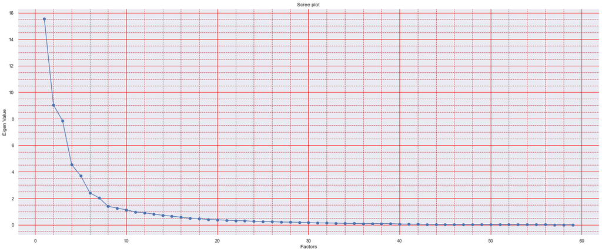

```python
sns.set()
plt.figure(figsize = (25,10))
plt.scatter(xvals, ev)
plt.plot(xvals, ev)
plt.title('Scree plot')
plt.xlabel('Factors')
plt.ylabel('Eigen Value')
plt.grid(color = 'red', )
plt.grid(b=True, which='minor', color='r', linestyle='--')
plt.minorticks_on()
plt.show()
```

```python
Factors  = pd.DataFrame.from_records(loadings)

Factors = Factors.add_prefix('Factor ')

Factors.index = fa_train_df.columns
Factors
```

|  | Factor 0 | Factor 1 | Factor 2 | Factor 3 | Factor 4 | Factor 5 | Factor 6 | Factor 7 | Factor 8 | Factor 9 | Factor 10 | Factor 11 | Factor 12 | Factor 13 | Factor 14 | Factor 15 | Factor 16 | Factor 17 | Factor 18 | Factor 19 | Factor 20 | Factor 21 | Factor 22 | Factor 23 | Factor 24 |
| --- | --- | --- | --- | --- | --- | --- | --- | --- | --- | --- | --- | --- | --- | --- | --- | --- | --- | --- | --- | --- | --- | --- | --- | --- | --- |
| rent_mean | 0.760475 | -0.063396 | 0.324753 | 0.157986 | -0.135593 | -0.147903 | 0.048739 | 0.144837 | 0.201937 | -0.029945 | 0.032643 | -0.172312 | 0.304989 | 0.212204 | -0.015387 | 0.004545 | -0.007256 | 0.079777 | 0.004312 | -0.108694 | -0.000491 | -0.047148 | 0.014647 | -0.004711 | -0.010032 |
| rent_median | 0.717884 | -0.059129 | 0.319583 | 0.139694 | -0.123943 | -0.165580 | 0.053359 | 0.152174 | 0.204098 | -0.035513 | 0.032402 | -0.166868 | 0.286058 | 0.227909 | -0.005667 | -0.008157 | 0.003158 | 0.085817 | 0.010972 | -0.102494 | 0.010825 | -0.041238 | -0.004926 | 0.050042 | 0.014248 |
| rent_stdev | 0.576379 | -0.067221 | 0.222542 | 0.187015 | -0.179919 | 0.065701 | 0.071393 | -0.005531 | 0.020369 | 0.028828 | 0.021184 | -0.110539 | 0.164670 | -0.006460 | -0.098141 | 0.026191 | -0.051800 | 0.013285 | -0.027837 | -0.006175 | -0.038594 | -0.004025 | 0.035104 | -0.115628 | -0.043294 |
| rent_sample_weight | -0.442516 | 0.360121 | 0.258555 | -0.124973 | -0.179440 | 0.558241 | -0.100781 | -0.012571 | -0.178091 | 0.005653 | 0.031236 | -0.046552 | 0.036845 | -0.054099 | 0.056830 | -0.047127 | 0.164843 | -0.041695 | -0.019587 | 0.004252 | -0.000901 | 0.024581 | 0.048694 | 0.004525 | 0.011805 |
| rent_samples | -0.157643 | 0.409892 | 0.470609 | -0.099507 | -0.303518 | 0.613789 | -0.099845 | 0.042845 | -0.058124 | -0.006608 | 0.034498 | -0.131068 | 0.118982 | -0.030657 | 0.110206 | -0.062670 | 0.089374 | -0.032599 | 0.006073 | -0.036534 | 0.007019 | 0.032428 | -0.001979 | 0.013600 | -0.006530 |
| rent_gt_10 | -0.072528 | 0.072656 | 0.328015 | 0.272110 | 0.193265 | -0.046130 | -0.169811 | 0.360298 | 0.034659 | -0.380909 | 0.054898 | 0.185669 | 0.013848 | -0.009853 | 0.252661 | 0.332729 | 0.036842 | -0.043483 | 0.004533 | 0.026546 | 0.085994 | -0.011809 | 0.013361 | -0.016960 | -0.002735 |
| rent_gt_15 | -0.127099 | 0.055246 | 0.456564 | 0.429299 | 0.200224 | -0.039068 | -0.155473 | 0.295623 | 0.016905 | -0.304454 | 0.062543 | 0.143220 | 0.018156 | -0.049715 | 0.006115 | 0.032237 | 0.019282 | -0.019570 | 0.005854 | 0.006636 | -0.057356 | 0.009325 | -0.006627 | 0.002950 | -0.002209 |
| rent_gt_20 | -0.226160 | 0.016619 | 0.519126 | 0.583447 | 0.196329 | -0.035268 | -0.135473 | 0.201811 | -0.008604 | -0.240004 | 0.066459 | 0.130638 | -0.000234 | -0.112601 | -0.207634 | -0.247818 | 0.009328 | 0.008153 | 0.008108 | -0.021835 | -0.186864 | 0.040859 | -0.010670 | 0.030148 | 0.012340 |
| rent_gt_25 | -0.283097 | -0.006203 | 0.516834 | 0.627992 | 0.165774 | -0.047905 | -0.094716 | 0.023931 | -0.023352 | -0.042871 | 0.029470 | 0.036053 | -0.016885 | -0.064116 | -0.118876 | -0.168646 | 0.006901 | 0.007535 | -0.001386 | -0.000946 | 0.076766 | -0.014105 | 0.006063 | -0.018296 | -0.004667 |
| rent_gt_30 | -0.310527 | -0.018712 | 0.512883 | 0.679912 | 0.155216 | -0.085214 | -0.088437 | -0.120305 | -0.013475 | 0.110316 | 0.011302 | -0.020357 | -0.022445 | -0.037514 | -0.038749 | -0.118793 | 0.022765 | 0.017254 | 0.001233 | 0.011097 | 0.292571 | -0.038556 | 0.016289 | -0.028667 | -0.004366 |
| rent_gt_35 | -0.303332 | -0.032649 | 0.489806 | 0.669785 | 0.124701 | -0.102566 | -0.084462 | -0.199870 | -0.007831 | 0.188397 | -0.011530 | -0.054880 | -0.015003 | 0.013048 | 0.058918 | 0.025551 | 0.028582 | -0.003534 | 0.004477 | 0.009974 | 0.056830 | 0.001289 | -0.002356 | 0.015476 | 0.005501 |
| rent_gt_40 | -0.299957 | -0.041694 | 0.477595 | 0.662098 | 0.112784 | -0.108338 | -0.087700 | -0.267211 | -0.004273 | 0.252295 | -0.025763 | -0.078018 | -0.015730 | 0.048564 | 0.137730 | 0.130798 | 0.029368 | -0.021802 | 0.004244 | 0.006622 | -0.139216 | 0.039686 | -0.013067 | 0.038719 | 0.014477 |
| rent_gt_50 | -0.273391 | -0.058043 | 0.428189 | 0.570540 | 0.077252 | -0.083559 | -0.073795 | -0.249037 | -0.004694 | 0.211822 | -0.026271 | -0.066190 | -0.007044 | 0.054383 | 0.096932 | 0.133906 | 0.006569 | -0.021469 | -0.001697 | -0.000437 | -0.133673 | 0.021434 | -0.006730 | -0.008403 | -0.004645 |
| hi_mean | 0.955017 | -0.042475 | -0.015172 | 0.002751 | -0.111454 | -0.163394 | 0.019603 | 0.003934 | 0.008861 | 0.027776 | 0.043088 | 0.002991 | 0.052533 | -0.049550 | -0.005776 | -0.014082 | 0.143521 | -0.046066 | 0.010486 | 0.021537 | 0.016529 | 0.027926 | -0.000831 | 0.051664 | 0.036061 |
| hi_median | 0.924299 | -0.025099 | -0.019047 | -0.034585 | -0.078977 | -0.221515 | 0.019983 | 0.032594 | 0.017929 | 0.024650 | 0.042108 | -0.020479 | 0.061076 | 0.047462 | -0.004869 | -0.033661 | 0.174416 | -0.069675 | 0.017359 | 0.061529 | 0.018545 | 0.077912 | 0.016035 | 0.041672 | 0.038073 |
| hi_stdev | 0.894348 | -0.085016 | -0.003761 | 0.110077 | -0.191813 | 0.019422 | 0.015756 | -0.097577 | -0.023820 | 0.050277 | 0.043311 | 0.057112 | 0.026522 | -0.277578 | -0.012190 | 0.049116 | 0.049310 | 0.022939 | -0.019143 | -0.068745 | -0.011178 | -0.096596 | -0.029695 | 0.043502 | 0.010455 |
| hi_sample_weight | -0.281855 | 0.851851 | -0.014944 | 0.105316 | -0.060737 | 0.363291 | -0.046057 | 0.013429 | -0.031180 | -0.013179 | -0.010661 | -0.044860 | 0.019037 | 0.008103 | 0.049502 | -0.024958 | 0.064910 | 0.115525 | -0.071584 | -0.018325 | -0.005316 | 0.019559 | 0.039573 | 0.007562 | -0.001407 |
| hi_samples | 0.225212 | 0.915959 | -0.018944 | 0.081977 | -0.106297 | 0.233828 | -0.054173 | 0.024860 | 0.001746 | 0.016073 | 0.014090 | -0.039265 | 0.014860 | 0.001359 | 0.000894 | 0.009070 | 0.072130 | 0.019897 | -0.003798 | -0.007218 | 0.006416 | 0.037033 | -0.094275 | -0.045134 | -0.039911 |
| family_mean | 0.951528 | -0.071286 | -0.041563 | 0.029775 | -0.130450 | -0.046964 | -0.051531 | -0.041000 | 0.010827 | 0.031449 | 0.038849 | 0.041157 | 0.039649 | -0.114755 | -0.030240 | 0.023160 | 0.169649 | -0.056173 | -0.017335 | 0.002862 | 0.004397 | 0.036658 | 0.016971 | -0.027949 | -0.011913 |
| family_median | 0.926729 | -0.069712 | -0.041594 | 0.016969 | -0.124799 | -0.083283 | -0.043708 | -0.033533 | 0.007342 | 0.029570 | 0.042705 | 0.021938 | 0.047056 | -0.031996 | -0.040652 | 0.005690 | 0.222026 | -0.076634 | -0.012518 | 0.052473 | 0.004611 | 0.100472 | 0.039036 | -0.045771 | -0.010862 |
| family_stdev | 0.826486 | -0.080479 | 0.006611 | 0.108359 | -0.182463 | 0.113900 | -0.047109 | -0.113731 | -0.011419 | 0.050483 | 0.040607 | 0.090860 | 0.017859 | -0.361059 | -0.006560 | 0.088637 | -0.000830 | 0.053819 | -0.032202 | -0.127774 | -0.014530 | -0.163451 | -0.050942 | 0.042377 | -0.006142 |
| family_sample_weight | -0.252024 | 0.889236 | -0.043062 | 0.095819 | -0.010307 | -0.005668 | 0.137770 | 0.045704 | -0.054491 | -0.030770 | -0.008883 | -0.055123 | -0.023474 | 0.030802 | 0.099364 | -0.070355 | -0.062034 | 0.107222 | -0.014075 | -0.014152 | 0.007725 | -0.009411 | 0.007419 | 0.111201 | 0.053548 |
| family_samples | 0.295321 | 0.913788 | -0.078433 | 0.086047 | -0.030528 | -0.097544 | 0.082155 | 0.041502 | -0.043413 | 0.008153 | 0.022731 | -0.026307 | -0.029268 | 0.021908 | 0.039893 | -0.032740 | -0.031082 | -0.019087 | 0.042931 | 0.010965 | 0.013664 | 0.004850 | -0.111816 | 0.045985 | 0.011947 |
| hc_mortgage_mean | 0.814993 | -0.140474 | 0.325411 | 0.149810 | -0.268517 | 0.089431 | 0.170773 | -0.007925 | -0.009386 | -0.059764 | -0.030017 | -0.023798 | 0.007556 | -0.036564 | 0.031405 | -0.014993 | -0.127737 | 0.051610 | -0.020684 | 0.228789 | 0.004526 | 0.036517 | -0.042243 | 0.016571 | -0.005729 |
| hc_mortgage_median | 0.795080 | -0.141585 | 0.335093 | 0.140629 | -0.267696 | 0.071978 | 0.165425 | -0.002397 | -0.014264 | -0.055453 | -0.023408 | -0.033499 | 0.012748 | 0.005760 | 0.017598 | -0.023626 | -0.078933 | 0.036438 | -0.028372 | 0.222832 | 0.001743 | 0.024204 | -0.037743 | 0.012913 | -0.006095 |
| hc_mortgage_stdev | 0.705367 | -0.115090 | 0.116148 | 0.184739 | -0.193527 | 0.149544 | 0.161691 | -0.053032 | 0.001112 | -0.037338 | -0.040465 | 0.022037 | 0.023870 | -0.189196 | 0.040172 | 0.038596 | -0.186374 | 0.086590 | 0.028589 | 0.032570 | 0.012303 | 0.056611 | 0.004357 | 0.009138 | 0.003621 |
| hc_mortgage_sample_weight | 0.033047 | 0.778903 | -0.334362 | -0.005133 | 0.251696 | -0.177235 | -0.116068 | 0.076850 | -0.010700 | 0.092182 | 0.006542 | -0.021275 | -0.101142 | 0.009823 | -0.062065 | 0.055096 | 0.046883 | 0.103063 | -0.027326 | -0.060800 | -0.003642 | 0.029168 | -0.031994 | -0.023645 | -0.011780 |
| hc_mortgage_samples | 0.513082 | 0.741510 | -0.124765 | 0.040872 | 0.160367 | -0.212380 | -0.057590 | 0.101651 | -0.010681 | 0.085386 | 0.011306 | -0.029822 | -0.115763 | 0.012863 | -0.105498 | 0.070085 | -0.004833 | -0.033432 | 0.056857 | -0.003122 | 0.011123 | 0.026549 | -0.175794 | -0.065234 | -0.055468 |
| hc_mean | 0.729933 | -0.164216 | 0.228162 | 0.159747 | -0.320547 | 0.136792 | 0.075345 | -0.058224 | -0.130386 | -0.110697 | 0.056043 | 0.053869 | -0.360063 | 0.237103 | -0.022284 | 0.003281 | 0.042919 | 0.028929 | -0.025900 | -0.054316 | -0.006480 | -0.045709 | 0.014314 | 0.002730 | 0.005630 |
| hc_median | 0.699403 | -0.157526 | 0.232314 | 0.147746 | -0.311856 | 0.125937 | 0.067263 | -0.053286 | -0.129474 | -0.110635 | 0.055567 | 0.046140 | -0.353456 | 0.269477 | -0.017734 | -0.017562 | 0.081992 | 0.008263 | -0.066166 | 0.005507 | -0.022560 | -0.127875 | -0.003589 | 0.016911 | -0.008314 |
| hc_stdev | 0.561939 | -0.123664 | 0.080254 | 0.206635 | -0.320587 | 0.162003 | 0.125380 | -0.099886 | -0.044677 | -0.079135 | 0.063068 | 0.056884 | -0.172053 | -0.014550 | -0.042649 | 0.082938 | -0.126018 | 0.098545 | 0.143272 | -0.209438 | 0.048299 | 0.226163 | 0.052145 | -0.032980 | 0.031686 |
| hc_samples | 0.040439 | 0.561232 | -0.628977 | 0.326710 | -0.046385 | -0.026349 | 0.107329 | -0.170841 | 0.120835 | -0.090955 | -0.036964 | 0.164540 | 0.026026 | 0.043475 | -0.008263 | 0.014043 | 0.057321 | 0.153542 | -0.112133 | 0.039836 | -0.011615 | -0.003361 | 0.029440 | -0.043003 | -0.004678 |
| hc_sample_weight | -0.169444 | 0.545713 | -0.643613 | 0.263688 | 0.008750 | -0.061522 | 0.103571 | -0.161872 | 0.148816 | -0.068360 | -0.048989 | 0.152687 | 0.096661 | -0.012601 | 0.004545 | 0.010519 | 0.057761 | 0.212068 | -0.131802 | 0.065041 | -0.012236 | 0.011093 | 0.060101 | -0.020926 | 0.011175 |
| home_equity_second_mortgage | 0.192335 | 0.096893 | 0.356434 | -0.235778 | 0.603279 | 0.172285 | 0.307161 | -0.202241 | 0.214858 | -0.100238 | 0.224971 | -0.057741 | -0.040680 | -0.010292 | 0.014839 | -0.008350 | 0.019648 | -0.018387 | -0.002955 | -0.005290 | -0.003850 | -0.002212 | -0.020886 | -0.006489 | 0.000160 |
| second_mortgage | 0.215819 | 0.088124 | 0.381661 | -0.228729 | 0.619787 | 0.179319 | 0.335505 | -0.220679 | 0.245391 | -0.116570 | 0.262595 | -0.080559 | -0.053972 | -0.027160 | 0.017445 | -0.009297 | 0.010049 | -0.024816 | -0.012084 | 0.017413 | -0.003317 | -0.006945 | -0.012156 | -0.019474 | -0.010109 |
| home_equity | 0.630631 | 0.019653 | 0.309765 | -0.114517 | 0.488296 | 0.170592 | 0.126872 | -0.029844 | -0.178880 | 0.045086 | -0.333849 | 0.200159 | 0.107455 | 0.081181 | -0.002301 | -0.014707 | 0.015534 | 0.005554 | 0.019699 | -0.026695 | 0.003316 | 0.000128 | -0.022276 | 0.000484 | 0.003772 |
| debt | 0.505040 | 0.173117 | 0.509058 | -0.268231 | 0.272997 | -0.112529 | -0.164514 | 0.307669 | -0.112910 | 0.169688 | -0.022476 | -0.226403 | -0.168556 | -0.104961 | -0.001345 | 0.035947 | -0.025608 | 0.130037 | -0.089341 | 0.026707 | -0.016088 | 0.001292 | 0.098942 | -0.012594 | 0.009242 |
| second_mortgage_cdf | -0.319169 | -0.144912 | -0.201991 | 0.165774 | -0.599197 | -0.084956 | -0.223079 | 0.143555 | -0.116589 | 0.062340 | -0.211193 | 0.068899 | 0.055675 | 0.036403 | 0.011418 | -0.023526 | -0.004966 | -0.003101 | 0.004412 | 0.009659 | 0.000423 | -0.007173 | -0.049016 | -0.020689 | -0.008299 |
| home_equity_cdf | -0.650725 | -0.041394 | -0.272858 | 0.101310 | -0.503442 | -0.161047 | -0.095260 | 0.018293 | 0.183264 | -0.046718 | 0.273186 | -0.160719 | -0.072992 | -0.061999 | 0.008944 | -0.006516 | -0.002442 | -0.016210 | -0.011953 | 0.038559 | -0.001788 | 0.001893 | -0.015489 | -0.008576 | -0.004735 |
| debt_cdf | -0.494496 | -0.162408 | -0.530212 | 0.271567 | -0.252608 | 0.133740 | 0.144241 | -0.300614 | 0.080905 | -0.163883 | 0.039203 | 0.215225 | 0.152797 | 0.091662 | 0.008022 | -0.023275 | 0.017787 | -0.093144 | 0.074951 | -0.031655 | 0.012455 | -0.001113 | -0.050793 | 0.023976 | 0.000623 |
| hs_degree | 0.687511 | 0.003140 | -0.254227 | -0.042930 | 0.178590 | 0.205403 | -0.545724 | -0.054562 | 0.054694 | 0.104744 | 0.178030 | 0.126526 | 0.036558 | 0.088557 | 0.029986 | -0.043100 | -0.096567 | 0.004975 | 0.003411 | 0.025830 | 0.001183 | -0.000155 | 0.005058 | 0.003675 | 0.005470 |
| hs_degree_male | 0.680387 | 0.004870 | -0.221397 | -0.041693 | 0.158627 | 0.208617 | -0.527774 | -0.048292 | 0.041752 | 0.096522 | 0.172624 | 0.103821 | 0.048554 | 0.080605 | 0.038026 | -0.046715 | -0.101955 | -0.014678 | -0.017031 | 0.028530 | -0.008603 | -0.029669 | -0.034913 | -0.100551 | 0.210723 |
| hs_degree_female | 0.652225 | 0.001020 | -0.274125 | -0.043365 | 0.185522 | 0.189771 | -0.525977 | -0.055940 | 0.071324 | 0.111171 | 0.168921 | 0.147791 | 0.020485 | 0.087252 | 0.010656 | -0.030816 | -0.084727 | 0.018428 | 0.024689 | 0.022612 | 0.011859 | 0.028637 | 0.053779 | 0.121820 | -0.195526 |
| male_age_mean | 0.264362 | -0.194492 | -0.634425 | 0.430888 | 0.131008 | 0.325858 | 0.071820 | 0.143056 | 0.172480 | 0.032734 | -0.124445 | -0.105352 | -0.068353 | -0.028651 | 0.031402 | -0.016955 | 0.024826 | 0.004615 | 0.132805 | 0.021179 | -0.027028 | -0.056980 | 0.051514 | -0.060069 | -0.023864 |
| male_age_median | 0.335537 | -0.171819 | -0.637608 | 0.404396 | 0.159464 | 0.238244 | 0.099692 | 0.169336 | 0.175849 | 0.052286 | -0.137514 | -0.113516 | -0.113615 | -0.033222 | 0.073704 | -0.057982 | 0.057420 | 0.014286 | 0.245268 | 0.057008 | -0.032025 | -0.066943 | 0.046881 | -0.016580 | 0.003551 |
| male_age_stdev | 0.049833 | -0.020338 | -0.511379 | 0.293379 | 0.195964 | -0.023146 | 0.198547 | 0.016471 | -0.500323 | -0.023083 | 0.270908 | -0.084296 | 0.145184 | 0.040058 | 0.002936 | 0.017083 | -0.039532 | 0.013416 | 0.047769 | 0.021290 | -0.004146 | -0.017999 | 0.003733 | 0.005047 | -0.021784 |
| male_age_sample_weight | 0.153491 | 0.884079 | 0.167072 | 0.007167 | -0.157445 | -0.067401 | 0.025378 | -0.066505 | 0.092770 | 0.008608 | -0.067567 | 0.063505 | 0.002670 | -0.007495 | -0.104401 | 0.054856 | -0.101755 | -0.192699 | 0.015094 | 0.016110 | 0.003899 | -0.032626 | 0.139922 | 0.059906 | 0.037784 |
| male_age_samples | 0.199813 | 0.921159 | 0.115816 | 0.019202 | -0.135034 | -0.059659 | 0.083009 | 0.009413 | 0.045143 | 0.024259 | -0.022885 | 0.012747 | -0.004096 | -0.004176 | -0.081580 | 0.048483 | -0.050782 | -0.117672 | 0.039383 | 0.014613 | 0.020505 | -0.002236 | 0.023903 | 0.102677 | 0.047691 |
| female_age_mean | 0.201879 | -0.190332 | -0.615134 | 0.465952 | 0.163001 | 0.376516 | 0.071278 | 0.162027 | 0.078768 | 0.015610 | -0.081004 | -0.143334 | -0.013603 | 0.011877 | -0.061504 | 0.045490 | -0.063957 | -0.154068 | -0.224840 | -0.057668 | 0.019503 | 0.036551 | -0.022459 | -0.000447 | -0.005702 |
| female_age_median | 0.271309 | -0.167022 | -0.636358 | 0.441313 | 0.197093 | 0.257314 | 0.100192 | 0.166995 | 0.076976 | 0.026077 | -0.087944 | -0.131078 | -0.052982 | 0.011812 | -0.033646 | 0.015710 | -0.052630 | -0.144324 | -0.152757 | -0.030609 | 0.024630 | 0.043907 | -0.034965 | 0.064749 | 0.018819 |
| female_age_stdev | -0.057830 | -0.020947 | -0.433317 | 0.234013 | 0.158127 | 0.047137 | 0.201101 | 0.028094 | -0.519360 | 0.011587 | 0.271717 | -0.049154 | 0.172832 | 0.030659 | -0.105487 | 0.102581 | -0.019302 | -0.019412 | 0.005839 | 0.031296 | -0.009195 | -0.036363 | 0.053817 | -0.020868 | 0.007135 |
| female_age_sample_weight | 0.152581 | 0.891817 | 0.174671 | 0.035905 | -0.146199 | -0.036469 | -0.008760 | -0.066913 | 0.031751 | -0.009956 | -0.025024 | 0.028962 | 0.010491 | 0.008142 | -0.008001 | -0.010035 | -0.072527 | -0.116760 | 0.072468 | 0.011221 | -0.031218 | -0.066162 | 0.084383 | -0.103241 | -0.037144 |
| female_age_samples | 0.204339 | 0.938734 | 0.114113 | 0.058287 | -0.116408 | -0.031715 | 0.054665 | 0.012574 | -0.027062 | 0.003967 | 0.020093 | -0.027862 | 0.009315 | 0.014677 | -0.000599 | -0.007924 | -0.040856 | -0.072341 | 0.070437 | 0.006230 | -0.011453 | -0.039044 | -0.013968 | -0.063574 | -0.024719 |
| pct_own | 0.458917 | 0.073366 | -0.592291 | 0.154113 | 0.281658 | -0.430103 | 0.023573 | -0.015681 | 0.000110 | 0.020507 | -0.001858 | 0.066372 | -0.105172 | -0.011723 | -0.037935 | 0.014429 | 0.034496 | -0.027504 | -0.007243 | -0.004017 | 0.002131 | 0.019618 | 0.072022 | 0.021810 | 0.015222 |
| married | 0.530469 | 0.126577 | -0.475233 | 0.108788 | 0.126237 | -0.278091 | 0.157451 | 0.121383 | -0.115889 | 0.039668 | 0.092487 | 0.005807 | -0.034299 | -0.057316 | 0.347440 | -0.245700 | 0.004440 | -0.014440 | 0.034714 | -0.065053 | -0.005750 | 0.022946 | -0.004219 | 0.017623 | 0.010128 |
| married_snp | -0.359319 | -0.060522 | 0.291031 | 0.034920 | -0.192854 | 0.125582 | 0.452835 | 0.370047 | 0.154781 | 0.446643 | 0.208373 | 0.336639 | 0.000258 | 0.022526 | -0.001232 | 0.011554 | -0.009018 | -0.013392 | -0.024897 | 0.001368 | -0.007763 | -0.009394 | 0.033368 | -0.000125 | 0.013422 |
| separated | -0.358463 | -0.051877 | 0.158742 | 0.028419 | -0.073453 | 0.116475 | 0.255099 | 0.253754 | 0.082282 | 0.302906 | 0.160234 | 0.241980 | -0.008934 | 0.045856 | -0.017830 | 0.010603 | 0.033325 | 0.036418 | 0.001739 | 0.011507 | 0.004101 | 0.017061 | -0.044573 | -0.018012 | -0.016832 |
| divorced | -0.393144 | -0.042448 | -0.205136 | 0.018705 | 0.162162 | 0.281798 | -0.118419 | 0.059024 | 0.047672 | 0.035145 | 0.027052 | -0.081083 | -0.001260 | 0.027122 | -0.222980 | 0.165851 | 0.107426 | 0.139104 | 0.179138 | 0.082218 | 0.026828 | -0.005419 | -0.033829 | 0.100116 | 0.065911 |
| Bad_Debt | 0.628268 | 0.018681 | 0.323725 | -0.114805 | 0.495392 | 0.170665 | 0.140063 | -0.037879 | -0.155709 | 0.035808 | -0.300118 | 0.178835 | 0.095648 | 0.068463 | -0.001847 | -0.013353 | 0.008333 | 0.003834 | 0.013991 | -0.013109 | 0.003747 | -0.001441 | -0.010072 | -0.003343 | -0.001204 |

```python
fa = FactorAnalyzer( rotation="varimax", n_factors = 12)
fa.fit(fa_train_df)
loadings = fa.loadings_
```

```python
Factors  = pd.DataFrame.from_records(loadings)

Factors = Factors.add_prefix('Factor ')

Factors.index = fa_train_df.columns
Factors
```

|  | Factor 0 | Factor 1 | Factor 2 | Factor 3 | Factor 4 | Factor 5 | Factor 6 | Factor 7 | Factor 8 | Factor 9 | Factor 10 | Factor 11 |
| --- | --- | --- | --- | --- | --- | --- | --- | --- | --- | --- | --- | --- |
| rent_mean | 0.789021 | 0.040012 | 0.038941 | -0.021709 | 0.069256 | 0.121732 | 0.088021 | 0.057797 | 0.145601 | 0.137848 | -0.097677 | 0.488285 |
| rent_median | 0.742003 | 0.038226 | 0.031515 | -0.035057 | 0.053643 | 0.134560 | 0.089465 | 0.052404 | 0.149594 | 0.141333 | -0.102608 | 0.451314 |
| rent_stdev | 0.659926 | 0.018945 | 0.085863 | 0.045249 | 0.049560 | -0.056153 | 0.034718 | 0.061515 | 0.051932 | -0.000088 | 0.009946 | 0.200770 |
| rent_sample_weight | -0.292390 | 0.250003 | 0.042910 | -0.151727 | -0.102631 | -0.765664 | -0.035708 | -0.005133 | -0.012322 | 0.009249 | 0.008005 | -0.120576 |
| rent_samples | 0.039249 | 0.330013 | 0.052201 | -0.180707 | -0.094791 | -0.865473 | 0.013352 | -0.004131 | 0.062554 | 0.059024 | -0.115426 | 0.033950 |
| rent_gt_10 | -0.030330 | 0.047236 | 0.208386 | -0.042875 | -0.004896 | -0.023455 | 0.041221 | 0.041593 | 0.076880 | 0.566371 | -0.043635 | 0.024176 |
| rent_gt_15 | -0.011144 | 0.032773 | 0.375047 | -0.050537 | -0.044303 | -0.053456 | 0.043662 | 0.030643 | 0.049670 | 0.796898 | -0.030208 | 0.015848 |
| rent_gt_20 | -0.035040 | 0.001215 | 0.585450 | -0.038916 | -0.106707 | -0.081913 | 0.032065 | 0.014050 | 0.023625 | 0.635572 | -0.009829 | -0.012261 |
| rent_gt_25 | -0.055213 | -0.012471 | 0.746023 | -0.037572 | -0.137342 | -0.081977 | 0.018918 | 0.001528 | 0.012203 | 0.444079 | 0.001319 | -0.022066 |
| rent_gt_30 | -0.067113 | -0.015637 | 0.865941 | -0.039781 | -0.135501 | -0.056896 | 0.011162 | -0.012296 | 0.003153 | 0.264620 | -0.004715 | -0.007321 |
| rent_gt_35 | -0.057654 | -0.021511 | 0.938392 | -0.045885 | -0.119311 | -0.039949 | -0.006243 | -0.016248 | -0.001093 | 0.122730 | -0.012411 | 0.009594 |
| rent_gt_40 | -0.056545 | -0.028555 | 0.941935 | -0.052699 | -0.107208 | -0.038135 | -0.010077 | -0.014898 | -0.009015 | 0.045565 | -0.020553 | 0.014763 |
| rent_gt_50 | -0.044499 | -0.047820 | 0.831141 | -0.060800 | -0.100731 | -0.051270 | -0.015498 | -0.015243 | -0.025855 | 0.026344 | -0.023490 | 0.012218 |
| hi_mean | 0.829689 | 0.081603 | -0.193967 | 0.041917 | 0.291149 | 0.295301 | 0.054728 | 0.103674 | 0.134906 | -0.075720 | 0.020428 | 0.119954 |
| hi_median | 0.775399 | 0.091510 | -0.214237 | 0.013129 | 0.278033 | 0.337109 | 0.062767 | 0.103761 | 0.162272 | -0.065303 | 0.019274 | 0.156885 |
| hi_stdev | 0.846488 | 0.041184 | -0.095019 | 0.113473 | 0.284510 | 0.128669 | 0.021573 | 0.088188 | 0.035394 | -0.113191 | 0.025435 | 0.002889 |
| hi_sample_weight | -0.302913 | 0.798058 | 0.057955 | 0.078790 | -0.025504 | -0.449996 | -0.013072 | -0.022945 | -0.080585 | 0.050407 | 0.025856 | -0.049955 |
| hi_samples | 0.110619 | 0.926326 | -0.053162 | 0.076272 | 0.141768 | -0.262349 | 0.027480 | 0.019410 | 0.023996 | 0.010151 | 0.003032 | 0.009502 |
| family_mean | 0.828524 | 0.049253 | -0.176453 | 0.096145 | 0.369300 | 0.202573 | 0.033460 | 0.104102 | 0.089748 | -0.087935 | -0.000114 | 0.065291 |
| family_median | 0.801321 | 0.047836 | -0.178996 | 0.074197 | 0.350845 | 0.224058 | 0.031119 | 0.097554 | 0.096293 | -0.087444 | 0.009746 | 0.087205 |
| family_stdev | 0.773963 | 0.029345 | -0.078128 | 0.129495 | 0.315857 | 0.039352 | 0.020384 | 0.089643 | 0.021994 | -0.094709 | -0.006741 | -0.025575 |
| family_sample_weight | -0.290470 | 0.860767 | 0.038449 | -0.028340 | -0.185132 | -0.089482 | 0.010133 | -0.036523 | -0.039670 | 0.052749 | 0.093189 | -0.031429 |
| family_samples | 0.139673 | 0.953192 | -0.071167 | 0.003947 | 0.054655 | 0.089947 | 0.046805 | 0.026467 | 0.062615 | 0.008815 | 0.090933 | 0.007330 |
| hc_mortgage_mean | 0.942393 | -0.022254 | 0.003640 | 0.011175 | 0.004836 | -0.032548 | 0.071605 | 0.130529 | 0.062018 | 0.034132 | -0.056303 | 0.018550 |
| hc_mortgage_median | 0.925628 | -0.026992 | 0.007762 | -0.009202 | -0.002076 | -0.030055 | 0.067052 | 0.124466 | 0.071186 | 0.035808 | -0.052206 | 0.032250 |
| hc_mortgage_stdev | 0.771064 | -0.003261 | -0.017650 | 0.154609 | 0.057231 | -0.013570 | 0.057544 | 0.125013 | -0.031623 | -0.023302 | -0.005783 | -0.012278 |
| hc_mortgage_sample_weight | -0.300656 | 0.772373 | -0.098838 | 0.117333 | 0.224082 | 0.246919 | 0.033721 | 0.012140 | 0.149346 | -0.025341 | 0.085891 | -0.025459 |
| hc_mortgage_samples | 0.209495 | 0.791455 | -0.098561 | 0.069911 | 0.260278 | 0.293403 | 0.101181 | 0.092701 | 0.252832 | 0.013809 | 0.043897 | 0.005406 |
| hc_mean | 0.872354 | -0.051827 | -0.008293 | 0.025025 | 0.081870 | -0.049513 | 0.004439 | 0.016034 | 0.060164 | 0.040460 | -0.018364 | -0.310883 |
| hc_median | 0.831823 | -0.050818 | -0.006428 | 0.010195 | 0.079423 | -0.049352 | 0.002619 | 0.018487 | 0.063249 | 0.041262 | -0.020441 | -0.274335 |
| hc_stdev | 0.697744 | -0.018593 | -0.000199 | 0.114021 | 0.038425 | -0.058762 | -0.020936 | -0.030230 | -0.077644 | -0.023627 | 0.013131 | -0.168431 |
| hc_samples | -0.097223 | 0.629439 | -0.068681 | 0.397885 | 0.121332 | 0.243475 | -0.113148 | -0.089472 | -0.461786 | -0.086966 | 0.126077 | -0.043946 |
| hc_sample_weight | -0.310923 | 0.578921 | -0.062640 | 0.353524 | 0.062729 | 0.235259 | -0.115807 | -0.104263 | -0.461142 | -0.100599 | 0.117901 | 0.017163 |
| home_equity_second_mortgage | 0.035851 | 0.030256 | 0.008863 | -0.089052 | -0.001548 | -0.035698 | 0.905542 | 0.175228 | 0.065388 | 0.034480 | -0.057768 | 0.016586 |
| second_mortgage | 0.067418 | 0.023287 | 0.020624 | -0.085433 | -0.010200 | -0.033926 | 0.967571 | 0.147069 | 0.064568 | 0.038708 | -0.062373 | 0.014352 |
| home_equity | 0.381937 | 0.026935 | -0.024957 | 0.000623 | 0.172420 | 0.029206 | 0.361087 | 0.809731 | 0.156351 | 0.049484 | -0.010751 | 0.018266 |
| debt | 0.310563 | 0.157140 | -0.027205 | -0.241165 | 0.145058 | 0.024562 | 0.249192 | 0.245264 | 0.750527 | 0.122191 | -0.119416 | 0.028414 |
| second_mortgage_cdf | -0.088111 | -0.107912 | 0.019417 | 0.007253 | -0.117169 | -0.090330 | -0.774682 | -0.183121 | -0.135384 | -0.027167 | -0.042840 | -0.000620 |
| home_equity_cdf | -0.381215 | -0.050912 | 0.028408 | -0.026020 | -0.217667 | -0.046808 | -0.376446 | -0.746963 | -0.197439 | -0.052706 | -0.021528 | -0.000058 |
| debt_cdf | -0.315979 | -0.149139 | 0.022326 | 0.258084 | -0.111850 | -0.036980 | -0.244838 | -0.242864 | -0.751708 | -0.121454 | 0.151244 | -0.046222 |
| hs_degree | 0.330834 | 0.029097 | -0.165616 | 0.225304 | 0.866310 | -0.005369 | 0.066930 | 0.064640 | 0.125856 | -0.033689 | -0.004815 | 0.060450 |
| hs_degree_male | 0.347975 | 0.032828 | -0.160559 | 0.207360 | 0.802019 | -0.015616 | 0.062763 | 0.072629 | 0.130850 | -0.029306 | -0.001349 | 0.062445 |
| hs_degree_female | 0.300928 | 0.029297 | -0.170518 | 0.235183 | 0.803285 | 0.028157 | 0.063811 | 0.068766 | 0.110956 | -0.041388 | -0.013674 | 0.042950 |
| male_age_mean | 0.122631 | -0.085682 | -0.065478 | 0.913235 | 0.130293 | 0.104775 | -0.059422 | -0.006027 | -0.107807 | -0.046732 | 0.084528 | -0.005913 |
| male_age_median | 0.161157 | -0.052976 | -0.092536 | 0.872429 | 0.129297 | 0.204770 | -0.040396 | 0.010207 | -0.054947 | -0.056263 | 0.088150 | -0.013150 |
| male_age_stdev | -0.040713 | 0.017978 | -0.023633 | 0.295852 | 0.058230 | 0.177173 | -0.029171 | -0.014056 | -0.086860 | -0.034580 | 0.859240 | -0.007595 |
| male_age_sample_weight | 0.108499 | 0.884899 | 0.019727 | -0.199644 | -0.005865 | -0.055349 | 0.026812 | 0.034457 | -0.024881 | 0.005791 | -0.151323 | 0.020643 |
| male_age_samples | 0.133978 | 0.937625 | -0.024449 | -0.137432 | -0.038063 | -0.039567 | 0.043924 | 0.025528 | 0.036177 | 0.007082 | -0.070273 | 0.032342 |
| female_age_mean | 0.075875 | -0.095166 | -0.029350 | 0.877510 | 0.126751 | 0.038853 | -0.056413 | 0.002319 | -0.109174 | -0.008576 | 0.197960 | 0.009012 |
| female_age_median | 0.106536 | -0.060526 | -0.055817 | 0.866467 | 0.125945 | 0.166771 | -0.038758 | 0.017605 | -0.067553 | -0.020762 | 0.199558 | -0.000182 |
| female_age_stdev | -0.110127 | -0.002930 | -0.021278 | 0.247954 | -0.000866 | 0.068087 | -0.045231 | 0.004096 | -0.088347 | -0.045298 | 0.719968 | -0.020947 |
| female_age_sample_weight | 0.110601 | 0.893191 | 0.045047 | -0.203096 | 0.029983 | -0.097395 | 0.026160 | 0.023393 | -0.013725 | 0.028621 | -0.090691 | 0.014454 |
| female_age_samples | 0.136863 | 0.954957 | 0.001722 | -0.131260 | -0.002110 | -0.076364 | 0.043767 | 0.016854 | 0.052373 | 0.033467 | 0.013151 | 0.029508 |
| pct_own | 0.123590 | 0.176666 | -0.149570 | 0.328869 | 0.310353 | 0.749438 | 0.008302 | 0.039394 | -0.004898 | -0.081461 | 0.198183 | -0.041722 |
| married | 0.286620 | 0.224887 | -0.233893 | 0.294934 | 0.166046 | 0.487008 | 0.006630 | 0.031694 | 0.065997 | -0.074416 | 0.283470 | 0.022649 |
| married_snp | -0.089221 | -0.072213 | 0.110052 | -0.031297 | -0.545451 | -0.229939 | 0.002106 | -0.083934 | 0.073016 | 0.016060 | -0.063076 | 0.063247 |
| separated | -0.181802 | -0.076564 | 0.090799 | 0.019243 | -0.395944 | -0.194935 | -0.001805 | -0.073670 | 0.068161 | 0.019237 | -0.019084 | 0.041666 |
| divorced | -0.437719 | -0.099307 | 0.011740 | 0.236724 | 0.034533 | -0.208559 | 0.002501 | -0.070071 | -0.026605 | 0.002877 | 0.036770 | -0.013039 |
| Bad_Debt | 0.386428 | 0.024802 | -0.018312 | -0.001947 | 0.163962 | 0.028109 | 0.399610 | 0.774981 | 0.160535 | 0.052203 | -0.014262 | 0.017497 |

```python
#  • Highschool graduation rates
#                         • Median population age
#                         • Second mortgage statistics
#                         • Percent own
#                         • Bad debt expense

Factors_df = round(Factors.loc[['hs_degree', 'hs_degree_male', 'hs_degree_female',"male_age_median", "female_age_median", "home_equity_second_mortgage", 'second_mortgage', 'second_mortgage_cdf', 'pct_own', 'Bad_Debt'], :], 2)
```

```python
def color_negative_red(value):
  """
  Colors elements in a dateframe
  green if positive and red if
  negative. Does not color NaN
  values.
  """

  if value < -0.6:
    color = 'brown'
  elif value > 0.6:
    color = 'green'
  else:
    color = 'blue'

  return 'color: %s' % color
```

```python
Factors_df.style.applymap(color_negative_red)
```

|  | Factor 0 | Factor 1 | Factor 2 | Factor 3 | Factor 4 | Factor 5 | Factor 6 | Factor 7 | Factor 8 | Factor 9 | Factor 10 | Factor 11 |
| --- | --- | --- | --- | --- | --- | --- | --- | --- | --- | --- | --- | --- |
| hs_degree | 0.330000 | 0.030000 | -0.170000 | 0.230000 | 0.870000 | -0.010000 | 0.070000 | 0.060000 | 0.130000 | -0.030000 | -0.000000 | 0.060000 |
| hs_degree_male | 0.350000 | 0.030000 | -0.160000 | 0.210000 | 0.800000 | -0.020000 | 0.060000 | 0.070000 | 0.130000 | -0.030000 | -0.000000 | 0.060000 |
| hs_degree_female | 0.300000 | 0.030000 | -0.170000 | 0.240000 | 0.800000 | 0.030000 | 0.060000 | 0.070000 | 0.110000 | -0.040000 | -0.010000 | 0.040000 |
| male_age_median | 0.160000 | -0.050000 | -0.090000 | 0.870000 | 0.130000 | 0.200000 | -0.040000 | 0.010000 | -0.050000 | -0.060000 | 0.090000 | -0.010000 |
| female_age_median | 0.110000 | -0.060000 | -0.060000 | 0.870000 | 0.130000 | 0.170000 | -0.040000 | 0.020000 | -0.070000 | -0.020000 | 0.200000 | -0.000000 |
| home_equity_second_mortgage | 0.040000 | 0.030000 | 0.010000 | -0.090000 | -0.000000 | -0.040000 | 0.910000 | 0.180000 | 0.070000 | 0.030000 | -0.060000 | 0.020000 |
| second_mortgage | 0.070000 | 0.020000 | 0.020000 | -0.090000 | -0.010000 | -0.030000 | 0.970000 | 0.150000 | 0.060000 | 0.040000 | -0.060000 | 0.010000 |
| second_mortgage_cdf | -0.090000 | -0.110000 | 0.020000 | 0.010000 | -0.120000 | -0.090000 | -0.770000 | -0.180000 | -0.140000 | -0.030000 | -0.040000 | -0.000000 |
| pct_own | 0.120000 | 0.180000 | -0.150000 | 0.330000 | 0.310000 | 0.750000 | 0.010000 | 0.040000 | -0.000000 | -0.080000 | 0.200000 | -0.040000 |
| Bad_Debt | 0.390000 | 0.020000 | -0.020000 | -0.000000 | 0.160000 | 0.030000 | 0.400000 | 0.770000 | 0.160000 | 0.050000 | -0.010000 | 0.020000 |

# Looks like "Related parameters" are loading on Unique Factors.

```python
len(fa_train_df.columns)
```

```
59
```

```python
# Get variance of each factors
fact_variance  = fa.get_factor_variance()
fact_variance
```

```
(array([11.8093628 ,  8.87462738,  4.71407815,  4.40034679,  3.77193593,
         3.35575387,  3.02878697,  2.20823883,  2.02803283,  1.83414926,
         1.66211152,  0.78492779]),
 array([0.20015869, 0.15041741, 0.07989963, 0.07458215, 0.06393112,
        0.05687718, 0.05133537, 0.03742778, 0.03437344, 0.03108728,
        0.02817138, 0.01330386]),
 array([0.20015869, 0.3505761 , 0.43047573, 0.50505788, 0.568989  ,
        0.62586619, 0.67720156, 0.71462933, 0.74900277, 0.78009005,
        0.80826143, 0.82156529]))
```

```python
Factor_variance  = pd.DataFrame.from_records(fact_variance)

Factor_variance = Factor_variance.add_prefix('Factor ')

Factor_variance.index = ['SS Loadings', 'Proportion Var', 'Cumulative Var']
round(Factor_variance, 2)
```

|  | Factor 0 | Factor 1 | Factor 2 | Factor 3 | Factor 4 | Factor 5 | Factor 6 | Factor 7 | Factor 8 | Factor 9 | Factor 10 | Factor 11 |
| --- | --- | --- | --- | --- | --- | --- | --- | --- | --- | --- | --- | --- |
| SS Loadings | 11.81 | 8.87 | 4.71 | 4.40 | 3.77 | 3.36 | 3.03 | 2.21 | 2.03 | 1.83 | 1.66 | 0.78 |
| Proportion Var | 0.20 | 0.15 | 0.08 | 0.07 | 0.06 | 0.06 | 0.05 | 0.04 | 0.03 | 0.03 | 0.03 | 0.01 |
| Cumulative Var | 0.20 | 0.35 | 0.43 | 0.51 | 0.57 | 0.63 | 0.68 | 0.71 | 0.75 | 0.78 | 0.81 | 0.82 |

# Data Modeling :

# Project Task: Week 4

# 1. Build a linear Regression model to predict the total monthly expenditure for home mortgages loan. Please refer ‘deplotment_RE.xlsx’. Column hc_mortgage_mean is predicted variable. This is the mean monthly mortgage and owner costs of specified geographical location. Note: Exclude loans from prediction model which have NaN (Not a Number) values for hc_mortgage_mean. a) Run a model at a Nation level. If the accuracy levels and R square are not satisfactory proceed to below step. b) Run another model at State level. There are 52 states in USA. c) Keep below considerations while building a linear regression model. Data Modeling : • Variables should have significant impact on predicting Monthly mortgage and owner costs • Utilize all predictor variable to start with initial hypothesis • R square of 60 percent and above should be achieved • Ensure Multi-collinearity does not exist in dependent variables • Test if predicted variable is normally distributed

```python
train_df = pd.read_csv('train.csv')
```

```python
train_df.head()
```

|  | UID | BLOCKID | SUMLEVEL | COUNTYID | STATEID | state | state_ab | city | place | type | primary | zip_code | area_code | lat | lng | ALand | AWater | pop | male_pop | female_pop | rent_mean | rent_median | rent_stdev | rent_sample_weight | rent_samples | rent_gt_10 | rent_gt_15 | rent_gt_20 | rent_gt_25 | … |
| --- | --- | --- | --- | --- | --- | --- | --- | --- | --- | --- | --- | --- | --- | --- | --- | --- | --- | --- | --- | --- | --- | --- | --- | --- | --- | --- | --- | --- | --- | --- |
| 0 | 267822 | NaN | 140 | 53 | 36 | New York | NY | Hamilton | Hamilton | City | tract | 13346 | 315 | 42.840812 | -75.501524 | 202183361.0 | 1699120 | 5230 | 2612 | 2618 | 769.38638 | 784.0 | 232.63967 | 272.34441 | 362.0 | 0.86761 | 0.79155 | 0.59155 | 0.45634 | … |
| 1 | 246444 | NaN | 140 | 141 | 18 | Indiana | IN | South Bend | Roseland | City | tract | 46616 | 574 | 41.701441 | -86.266614 | 1560828.0 | 100363 | 2633 | 1349 | 1284 | 804.87924 | 848.0 | 253.46747 | 312.58622 | 513.0 | 0.97410 | 0.93227 | 0.69920 | 0.69920 | … |
| 2 | 245683 | NaN | 140 | 63 | 18 | Indiana | IN | Danville | Danville | City | tract | 46122 | 317 | 39.792202 | -86.515246 | 69561595.0 | 284193 | 6881 | 3643 | 3238 | 742.77365 | 703.0 | 323.39011 | 291.85520 | 378.0 | 0.95238 | 0.88624 | 0.79630 | 0.66667 | … |
| 3 | 279653 | NaN | 140 | 127 | 72 | Puerto Rico | PR | San Juan | Guaynabo | Urban | tract | 927 | 787 | 18.396103 | -66.104169 | 1105793.0 | 0 | 2700 | 1141 | 1559 | 803.42018 | 782.0 | 297.39258 | 259.30316 | 368.0 | 0.94693 | 0.87151 | 0.69832 | 0.61732 | … |
| 4 | 247218 | NaN | 140 | 161 | 20 | Kansas | KS | Manhattan | Manhattan City | City | tract | 66502 | 785 | 39.195573 | -96.569366 | 2554403.0 | 0 | 5637 | 2586 | 3051 | 938.56493 | 881.0 | 392.44096 | 1005.42886 | 1704.0 | 0.99286 | 0.98247 | 0.91688 | 0.84740 | … |

```python
train_df.isna().sum()
```

```
UID                                0
BLOCKID                        27321
SUMLEVEL                           0
COUNTYID                           0
STATEID                            0
state                              0
state_ab                           0
city                               0
place                              0
type                               0
primary                            0
zip_code                           0
area_code                          0
lat                                0
lng                                0
ALand                              0
AWater                             0
pop                                0
male_pop                           0
female_pop                         0
rent_mean                        314
rent_median                      314
rent_stdev                       314
rent_sample_weight               314
rent_samples                     314
rent_gt_10                       314
rent_gt_15                       314
rent_gt_20                       314
rent_gt_25                       314
rent_gt_30                       314
rent_gt_35                       314
rent_gt_40                       314
rent_gt_50                       314
universe_samples                   0
used_samples                       0
hi_mean                          268
hi_median                        268
hi_stdev                         268
hi_sample_weight                 268
hi_samples                       268
```

[output cut: 26 more lines]

```
male_age_median                  189
male_age_stdev                   189
male_age_sample_weight           189
male_age_samples                 189
female_age_mean                  206
female_age_median                206
female_age_stdev                 206
female_age_sample_weight         206
female_age_samples               206
pct_own                          268
married                          191
married_snp                      191
separated                        191
divorced                         191
dtype: int64
```

```python
hf.miss_df(train_df)
```

|  | count | percentage |
| --- | --- | --- |
| UID | 0 | 0.00 |
| BLOCKID | 27321 | 100.00 |
| SUMLEVEL | 0 | 0.00 |
| COUNTYID | 0 | 0.00 |
| STATEID | 0 | 0.00 |
| state | 0 | 0.00 |
| state_ab | 0 | 0.00 |
| city | 0 | 0.00 |
| place | 0 | 0.00 |
| type | 0 | 0.00 |
| primary | 0 | 0.00 |
| zip_code | 0 | 0.00 |
| area_code | 0 | 0.00 |
| lat | 0 | 0.00 |
| lng | 0 | 0.00 |
| ALand | 0 | 0.00 |
| AWater | 0 | 0.00 |
| pop | 0 | 0.00 |
| male_pop | 0 | 0.00 |
| female_pop | 0 | 0.00 |
| rent_mean | 314 | 1.15 |
| rent_median | 314 | 1.15 |
| rent_stdev | 314 | 1.15 |
| rent_sample_weight | 314 | 1.15 |
| rent_samples | 314 | 1.15 |
| rent_gt_10 | 314 | 1.15 |
| rent_gt_15 | 314 | 1.15 |
| rent_gt_20 | 314 | 1.15 |
| rent_gt_25 | 314 | 1.15 |
| rent_gt_30 | 314 | 1.15 |
| rent_gt_35 | 314 | 1.15 |
| rent_gt_40 | 314 | 1.15 |
| rent_gt_50 | 314 | 1.15 |
| universe_samples | 0 | 0.00 |
| used_samples | 0 | 0.00 |
| hi_mean | 268 | 0.98 |
| hi_median | 268 | 0.98 |
| hi_stdev | 268 | 0.98 |
| hi_sample_weight | 268 | 0.98 |
| hi_samples | 268 | 0.98 |
| family_mean | 298 | 1.09 |
| family_median | 298 | 1.09 |
| family_stdev | 298 | 1.09 |
| family_sample_weight | 298 | 1.09 |
| family_samples | 298 | 1.09 |
| hc_mortgage_mean | 573 | 2.10 |
| hc_mortgage_median | 573 | 2.10 |
| hc_mortgage_stdev | 573 | 2.10 |
| hc_mortgage_sample_weight | 573 | 2.10 |
| hc_mortgage_samples | 573 | 2.10 |
| hc_mean | 600 | 2.20 |
| hc_median | 600 | 2.20 |
| hc_stdev | 600 | 2.20 |
| hc_samples | 600 | 2.20 |
| hc_sample_weight | 600 | 2.20 |
| home_equity_second_mortgage | 457 | 1.67 |
| second_mortgage | 457 | 1.67 |
| home_equity | 457 | 1.67 |
| debt | 457 | 1.67 |
| second_mortgage_cdf | 457 | 1.67 |
| home_equity_cdf | 457 | 1.67 |
| debt_cdf | 457 | 1.67 |
| hs_degree | 190 | 0.70 |
| hs_degree_male | 200 | 0.73 |
| hs_degree_female | 223 | 0.82 |
| male_age_mean | 189 | 0.69 |
| male_age_median | 189 | 0.69 |
| male_age_stdev | 189 | 0.69 |
| male_age_sample_weight | 189 | 0.69 |
| male_age_samples | 189 | 0.69 |
| female_age_mean | 206 | 0.75 |
| female_age_median | 206 | 0.75 |
| female_age_stdev | 206 | 0.75 |
| female_age_sample_weight | 206 | 0.75 |
| female_age_samples | 206 | 0.75 |
| pct_own | 268 | 0.98 |
| married | 191 | 0.70 |
| married_snp | 191 | 0.70 |
| separated | 191 | 0.70 |
| divorced | 191 | 0.70 |

```python
hf.miss_df(train_df).sort_values(by='percentage', ascending=False)
```

|  | count | percentage |
| --- | --- | --- |
| BLOCKID | 27321 | 100.00 |
| hc_stdev | 600 | 2.20 |
| hc_sample_weight | 600 | 2.20 |
| hc_samples | 600 | 2.20 |
| hc_mean | 600 | 2.20 |
| hc_median | 600 | 2.20 |
| hc_mortgage_samples | 573 | 2.10 |
| hc_mortgage_stdev | 573 | 2.10 |
| hc_mortgage_median | 573 | 2.10 |
| hc_mortgage_mean | 573 | 2.10 |
| hc_mortgage_sample_weight | 573 | 2.10 |
| second_mortgage_cdf | 457 | 1.67 |
| second_mortgage | 457 | 1.67 |
| home_equity | 457 | 1.67 |
| debt | 457 | 1.67 |
| debt_cdf | 457 | 1.67 |
| home_equity_cdf | 457 | 1.67 |
| home_equity_second_mortgage | 457 | 1.67 |
| rent_gt_40 | 314 | 1.15 |
| rent_gt_10 | 314 | 1.15 |
| rent_gt_35 | 314 | 1.15 |
| rent_gt_30 | 314 | 1.15 |
| rent_gt_25 | 314 | 1.15 |
| rent_gt_20 | 314 | 1.15 |
| rent_gt_50 | 314 | 1.15 |
| rent_gt_15 | 314 | 1.15 |
| rent_samples | 314 | 1.15 |
| rent_sample_weight | 314 | 1.15 |
| rent_stdev | 314 | 1.15 |
| rent_median | 314 | 1.15 |
| rent_mean | 314 | 1.15 |
| family_samples | 298 | 1.09 |
| family_sample_weight | 298 | 1.09 |
| family_stdev | 298 | 1.09 |
| family_median | 298 | 1.09 |
| family_mean | 298 | 1.09 |
| hi_median | 268 | 0.98 |
| hi_stdev | 268 | 0.98 |
| pct_own | 268 | 0.98 |
| hi_samples | 268 | 0.98 |
| hi_mean | 268 | 0.98 |
| hi_sample_weight | 268 | 0.98 |
| hs_degree_female | 223 | 0.82 |
| female_age_median | 206 | 0.75 |
| female_age_mean | 206 | 0.75 |
| female_age_stdev | 206 | 0.75 |
| female_age_sample_weight | 206 | 0.75 |
| female_age_samples | 206 | 0.75 |
| hs_degree_male | 200 | 0.73 |
| married | 191 | 0.70 |
| married_snp | 191 | 0.70 |
| separated | 191 | 0.70 |
| hs_degree | 190 | 0.70 |
| divorced | 191 | 0.70 |
| male_age_stdev | 189 | 0.69 |
| male_age_sample_weight | 189 | 0.69 |
| male_age_mean | 189 | 0.69 |
| male_age_median | 189 | 0.69 |
| male_age_samples | 189 | 0.69 |
| SUMLEVEL | 0 | 0.00 |
| COUNTYID | 0 | 0.00 |
| STATEID | 0 | 0.00 |
| state | 0 | 0.00 |
| state_ab | 0 | 0.00 |
| city | 0 | 0.00 |
| place | 0 | 0.00 |
| type | 0 | 0.00 |
| primary | 0 | 0.00 |
| used_samples | 0 | 0.00 |
| universe_samples | 0 | 0.00 |
| zip_code | 0 | 0.00 |
| area_code | 0 | 0.00 |
| lat | 0 | 0.00 |
| lng | 0 | 0.00 |
| ALand | 0 | 0.00 |
| AWater | 0 | 0.00 |
| pop | 0 | 0.00 |
| male_pop | 0 | 0.00 |
| female_pop | 0 | 0.00 |
| UID | 0 | 0.00 |

```python
train_df.head()
```

|  | UID | BLOCKID | SUMLEVEL | COUNTYID | STATEID | state | state_ab | city | place | type | primary | zip_code | area_code | lat | lng | ALand | AWater | pop | male_pop | female_pop | rent_mean | rent_median | rent_stdev | rent_sample_weight | rent_samples | rent_gt_10 | rent_gt_15 | rent_gt_20 | rent_gt_25 | … |
| --- | --- | --- | --- | --- | --- | --- | --- | --- | --- | --- | --- | --- | --- | --- | --- | --- | --- | --- | --- | --- | --- | --- | --- | --- | --- | --- | --- | --- | --- | --- |
| 0 | 267822 | NaN | 140 | 53 | 36 | New York | NY | Hamilton | Hamilton | City | tract | 13346 | 315 | 42.840812 | -75.501524 | 202183361.0 | 1699120 | 5230 | 2612 | 2618 | 769.38638 | 784.0 | 232.63967 | 272.34441 | 362.0 | 0.86761 | 0.79155 | 0.59155 | 0.45634 | … |
| 1 | 246444 | NaN | 140 | 141 | 18 | Indiana | IN | South Bend | Roseland | City | tract | 46616 | 574 | 41.701441 | -86.266614 | 1560828.0 | 100363 | 2633 | 1349 | 1284 | 804.87924 | 848.0 | 253.46747 | 312.58622 | 513.0 | 0.97410 | 0.93227 | 0.69920 | 0.69920 | … |
| 2 | 245683 | NaN | 140 | 63 | 18 | Indiana | IN | Danville | Danville | City | tract | 46122 | 317 | 39.792202 | -86.515246 | 69561595.0 | 284193 | 6881 | 3643 | 3238 | 742.77365 | 703.0 | 323.39011 | 291.85520 | 378.0 | 0.95238 | 0.88624 | 0.79630 | 0.66667 | … |
| 3 | 279653 | NaN | 140 | 127 | 72 | Puerto Rico | PR | San Juan | Guaynabo | Urban | tract | 927 | 787 | 18.396103 | -66.104169 | 1105793.0 | 0 | 2700 | 1141 | 1559 | 803.42018 | 782.0 | 297.39258 | 259.30316 | 368.0 | 0.94693 | 0.87151 | 0.69832 | 0.61732 | … |
| 4 | 247218 | NaN | 140 | 161 | 20 | Kansas | KS | Manhattan | Manhattan City | City | tract | 66502 | 785 | 39.195573 | -96.569366 | 2554403.0 | 0 | 5637 | 2586 | 3051 | 938.56493 | 881.0 | 392.44096 | 1005.42886 | 1704.0 | 0.99286 | 0.98247 | 0.91688 | 0.84740 | … |

```python
null_data = train_df[train_df.isnull().any(axis=1)]
null_data
```

|  | UID | BLOCKID | SUMLEVEL | COUNTYID | STATEID | state | state_ab | city | place | type | primary | zip_code | area_code | lat | lng | ALand | AWater | pop | male_pop | female_pop | rent_mean | rent_median | rent_stdev | rent_sample_weight | rent_samples | rent_gt_10 | rent_gt_15 | rent_gt_20 | rent_gt_25 | … |
| --- | --- | --- | --- | --- | --- | --- | --- | --- | --- | --- | --- | --- | --- | --- | --- | --- | --- | --- | --- | --- | --- | --- | --- | --- | --- | --- | --- | --- | --- | --- |
| 0 | 267822 | NaN | 140 | 53 | 36 | New York | NY | Hamilton | Hamilton | City | tract | 13346 | 315 | 42.840812 | -75.501524 | 2.021834e+08 | 1699120 | 5230 | 2612 | 2618 | 769.38638 | 784.0 | 232.63967 | 272.34441 | 362.0 | 0.86761 | 0.79155 | 0.59155 | 0.45634 | … |
| 1 | 246444 | NaN | 140 | 141 | 18 | Indiana | IN | South Bend | Roseland | City | tract | 46616 | 574 | 41.701441 | -86.266614 | 1.560828e+06 | 100363 | 2633 | 1349 | 1284 | 804.87924 | 848.0 | 253.46747 | 312.58622 | 513.0 | 0.97410 | 0.93227 | 0.69920 | 0.69920 | … |
| 2 | 245683 | NaN | 140 | 63 | 18 | Indiana | IN | Danville | Danville | City | tract | 46122 | 317 | 39.792202 | -86.515246 | 6.956160e+07 | 284193 | 6881 | 3643 | 3238 | 742.77365 | 703.0 | 323.39011 | 291.85520 | 378.0 | 0.95238 | 0.88624 | 0.79630 | 0.66667 | … |
| 3 | 279653 | NaN | 140 | 127 | 72 | Puerto Rico | PR | San Juan | Guaynabo | Urban | tract | 927 | 787 | 18.396103 | -66.104169 | 1.105793e+06 | 0 | 2700 | 1141 | 1559 | 803.42018 | 782.0 | 297.39258 | 259.30316 | 368.0 | 0.94693 | 0.87151 | 0.69832 | 0.61732 | … |
| 4 | 247218 | NaN | 140 | 161 | 20 | Kansas | KS | Manhattan | Manhattan City | City | tract | 66502 | 785 | 39.195573 | -96.569366 | 2.554403e+06 | 0 | 5637 | 2586 | 3051 | 938.56493 | 881.0 | 392.44096 | 1005.42886 | 1704.0 | 0.99286 | 0.98247 | 0.91688 | 0.84740 | … |
| ... | ... | ... | ... | ... | ... | ... | ... | ... | ... | ... | ... | ... | ... | ... | ... | ... | ... | ... | ... | ... | ... | ... | ... | ... | ... | ... | ... | ... | ... | … |
| 27316 | 279212 | NaN | 140 | 43 | 72 | Puerto Rico | PR | Coamo | Coamo | Urban | tract | 769 | 787 | 18.076060 | -66.358379 | 6.970300e+05 | 0 | 1847 | 909 | 938 | 439.42839 | 419.0 | 140.29970 | 170.00000 | 170.0 | 1.00000 | 1.00000 | 1.00000 | 0.83333 | … |
| 27317 | 277856 | NaN | 140 | 91 | 42 | Pennsylvania | PA | Blue Bell | Blue Bell | Borough | tract | 19422 | 215 | 40.158138 | -75.307271 | 5.077337e+06 | 11786 | 4155 | 2116 | 2039 | 1813.19253 | 1788.0 | 492.92300 | 64.84927 | 471.0 | 0.85435 | 0.63261 | 0.50000 | 0.37391 | … |
| 27318 | 233000 | NaN | 140 | 87 | 8 | Colorado | CO | Weldona | Saddle Ridge | City | tract | 80653 | 970 | 40.410316 | -103.814003 | 1.323262e+09 | 17577610 | 2829 | 1465 | 1364 | 849.39107 | 834.0 | 336.47530 | 120.91448 | 195.0 | 0.93846 | 0.71282 | 0.54359 | 0.44615 | … |
| 27319 | 287425 | NaN | 140 | 439 | 48 | Texas | TX | Colleyville | Colleyville City | Town | tract | 76034 | 817 | 32.904866 | -97.162151 | 1.865230e+07 | 158882 | 11542 | 5727 | 5815 | 1972.45746 | 1843.0 | 633.02173 | 19.16328 | 157.0 | 1.00000 | 1.00000 | 0.75796 | 0.61146 | … |
| 27320 | 265371 | NaN | 140 | 3 | 32 | Nevada | NV | Las Vegas | Paradise | City | tract | 89123 | 702 | 36.064754 | -115.152237 | 7.796308e+06 | 0 | 3726 | 1815 | 1911 | 949.84199 | 924.0 | 198.82109 | 555.87526 | 1031.0 | 0.94956 | 0.87779 | 0.83705 | 0.63337 | … |

27321 rows × 80 columns

```python
train_df.drop('BLOCKID', axis=1, inplace=True)
```

```python
test_df.drop('BLOCKID', axis=1, inplace=True)
```

```python
train_df.isna().sum()
```

```
UID                              0
SUMLEVEL                         0
COUNTYID                         0
STATEID                          0
state                            0
state_ab                         0
city                             0
place                            0
type                             0
primary                          0
zip_code                         0
area_code                        0
lat                              0
lng                              0
ALand                            0
AWater                           0
pop                              0
male_pop                         0
female_pop                       0
rent_mean                      314
rent_median                    314
rent_stdev                     314
rent_sample_weight             314
rent_samples                   314
rent_gt_10                     314
rent_gt_15                     314
rent_gt_20                     314
rent_gt_25                     314
rent_gt_30                     314
rent_gt_35                     314
rent_gt_40                     314
rent_gt_50                     314
universe_samples                 0
used_samples                     0
hi_mean                        268
hi_median                      268
hi_stdev                       268
hi_sample_weight               268
hi_samples                     268
family_mean                    298
```

[output cut: 25 more lines]

```
male_age_median                189
male_age_stdev                 189
male_age_sample_weight         189
male_age_samples               189
female_age_mean                206
female_age_median              206
female_age_stdev               206
female_age_sample_weight       206
female_age_samples             206
pct_own                        268
married                        191
married_snp                    191
separated                      191
divorced                       191
dtype: int64
```

```python
test_df.isna().sum()
```

```
UID                              0
SUMLEVEL                         0
COUNTYID                         0
STATEID                          0
state                            0
state_ab                         0
city                             0
place                            0
type                             0
primary                          0
zip_code                         0
area_code                        0
lat                              0
lng                              0
ALand                            0
AWater                           0
pop                              0
male_pop                         0
female_pop                       0
rent_mean                      148
rent_median                    148
rent_stdev                     148
rent_sample_weight             148
rent_samples                   148
rent_gt_10                     149
rent_gt_15                     149
rent_gt_20                     149
rent_gt_25                     149
rent_gt_30                     149
rent_gt_35                     149
rent_gt_40                     149
rent_gt_50                     149
universe_samples                 0
used_samples                     0
hi_mean                        122
hi_median                      122
hi_stdev                       122
hi_sample_weight               122
hi_samples                     122
family_mean                    136
```

[output cut: 25 more lines]

```
male_age_median                 84
male_age_stdev                  84
male_age_sample_weight          84
male_age_samples                84
female_age_mean                 96
female_age_median               96
female_age_stdev                96
female_age_sample_weight        96
female_age_samples              96
pct_own                        122
married                         84
married_snp                     84
separated                       84
divorced                        84
dtype: int64
```

```python
train_df = train_df.dropna()
train_df = train_df.reset_index(drop=True)
```

```python
test_df = test_df.dropna()
test_df = test_df.reset_index(drop=True)
```

```python
train_df.shape
```

```
(26585, 79)
```

```python
test_df.shape
```

```
(11355, 79)
```

```python
train_df[cat_columns]
```

|  | UID | COUNTYID | STATEID | state | state_ab | city | place | type | zip_code | area_code |
| --- | --- | --- | --- | --- | --- | --- | --- | --- | --- | --- |
| 0 | 267822 | 53 | 36 | New York | NY | Hamilton | Hamilton | City | 13346 | 315 |
| 1 | 246444 | 141 | 18 | Indiana | IN | South Bend | Roseland | City | 46616 | 574 |
| 2 | 245683 | 63 | 18 | Indiana | IN | Danville | Danville | City | 46122 | 317 |
| 3 | 279653 | 127 | 72 | Puerto Rico | PR | San Juan | Guaynabo | Urban | 927 | 787 |
| 4 | 247218 | 161 | 20 | Kansas | KS | Manhattan | Manhattan City | City | 66502 | 785 |
| ... | ... | ... | ... | ... | ... | ... | ... | ... | ... | ... |
| 26580 | 279212 | 43 | 72 | Puerto Rico | PR | Coamo | Coamo | Urban | 769 | 787 |
| 26581 | 277856 | 91 | 42 | Pennsylvania | PA | Blue Bell | Blue Bell | Borough | 19422 | 215 |
| 26582 | 233000 | 87 | 8 | Colorado | CO | Weldona | Saddle Ridge | City | 80653 | 970 |
| 26583 | 287425 | 439 | 48 | Texas | TX | Colleyville | Colleyville City | Town | 76034 | 817 |
| 26584 | 265371 | 3 | 32 | Nevada | NV | Las Vegas | Paradise | City | 89123 | 702 |

26585 rows × 10 columns

```python
train_df[num_variables(train_df)]
```

|  | lat | lng | ALand | rent_mean | rent_median | rent_stdev | rent_sample_weight | rent_samples | rent_gt_10 | rent_gt_15 | rent_gt_20 | rent_gt_25 | rent_gt_30 | rent_gt_35 | rent_gt_40 | rent_gt_50 | hi_mean | hi_median | hi_stdev | hi_sample_weight | hi_samples | family_mean | family_median | family_stdev | family_sample_weight | family_samples | hc_mortgage_mean | hc_mortgage_median | hc_mortgage_stdev | … |
| --- | --- | --- | --- | --- | --- | --- | --- | --- | --- | --- | --- | --- | --- | --- | --- | --- | --- | --- | --- | --- | --- | --- | --- | --- | --- | --- | --- | --- | --- | --- |
| 0 | 42.840812 | -75.501524 | 2.021834e+08 | 769.38638 | 784.0 | 232.63967 | 272.34441 | 362.0 | 0.86761 | 0.79155 | 0.59155 | 0.45634 | 0.42817 | 0.18592 | 0.15493 | 0.12958 | 63125.28406 | 48120.0 | 49042.01206 | 1290.96240 | 2024.0 | 67994.14790 | 53245.0 | 47667.30119 | 884.33516 | 1491.0 | 1414.80295 | 1223.0 | 641.22898 | … |
| 1 | 41.701441 | -86.266614 | 1.560828e+06 | 804.87924 | 848.0 | 253.46747 | 312.58622 | 513.0 | 0.97410 | 0.93227 | 0.69920 | 0.69920 | 0.55179 | 0.41235 | 0.39044 | 0.27888 | 41931.92593 | 35186.0 | 31639.50203 | 838.74664 | 1127.0 | 50670.10337 | 43023.0 | 34715.57548 | 375.28798 | 554.0 | 864.41390 | 784.0 | 482.27020 | … |
| 2 | 39.792202 | -86.515246 | 6.956160e+07 | 742.77365 | 703.0 | 323.39011 | 291.85520 | 378.0 | 0.95238 | 0.88624 | 0.79630 | 0.66667 | 0.39153 | 0.39153 | 0.28307 | 0.15873 | 84942.68317 | 74964.0 | 56811.62186 | 1155.20980 | 2488.0 | 95262.51431 | 85395.0 | 49292.67664 | 709.74925 | 1889.0 | 1506.06758 | 1361.0 | 731.89394 | … |
| 3 | 18.396103 | -66.104169 | 1.105793e+06 | 803.42018 | 782.0 | 297.39258 | 259.30316 | 368.0 | 0.94693 | 0.87151 | 0.69832 | 0.61732 | 0.51397 | 0.46927 | 0.35754 | 0.32961 | 48733.67116 | 37845.0 | 45100.54010 | 928.32193 | 1267.0 | 56401.68133 | 44399.0 | 41082.90515 | 490.18479 | 729.0 | 1175.28642 | 1101.0 | 428.98751 | … |
| 4 | 39.195573 | -96.569366 | 2.554403e+06 | 938.56493 | 881.0 | 392.44096 | 1005.42886 | 1704.0 | 0.99286 | 0.98247 | 0.91688 | 0.84740 | 0.78247 | 0.60974 | 0.55455 | 0.44416 | 31834.15466 | 22497.0 | 34046.50907 | 1548.67477 | 1983.0 | 54053.42396 | 50272.0 | 39609.12605 | 244.08903 | 395.0 | 1192.58759 | 1125.0 | 327.49674 | … |
| ... | ... | ... | ... | ... | ... | ... | ... | ... | ... | ... | ... | ... | ... | ... | ... | ... | ... | ... | ... | ... | ... | ... | ... | ... | ... | ... | ... | ... | ... | … |
| 26580 | 18.076060 | -66.358379 | 6.970300e+05 | 439.42839 | 419.0 | 140.29970 | 170.00000 | 170.0 | 1.00000 | 1.00000 | 1.00000 | 0.83333 | 0.79012 | 0.79012 | 0.72222 | 0.62963 | 18515.67021 | 13317.0 | 23914.42656 | 648.39020 | 774.0 | 20889.14617 | 16760.0 | 23488.17854 | 346.58143 | 446.0 | 770.11560 | 828.0 | 157.85227 | … |
| 26581 | 40.158138 | -75.307271 | 5.077337e+06 | 1813.19253 | 1788.0 | 492.92300 | 64.84927 | 471.0 | 0.85435 | 0.63261 | 0.50000 | 0.37391 | 0.30870 | 0.30870 | 0.26304 | 0.23478 | 119889.08320 | 108284.0 | 77625.25547 | 518.53683 | 1431.0 | 118896.06830 | 113313.0 | 66663.51722 | 388.97237 | 1151.0 | 2210.84055 | 2202.0 | 713.03361 | … |
| 26582 | 40.410316 | -103.814003 | 1.323262e+09 | 849.39107 | 834.0 | 336.47530 | 120.91448 | 195.0 | 0.93846 | 0.71282 | 0.54359 | 0.44615 | 0.29744 | 0.23077 | 0.16923 | 0.09231 | 79890.25113 | 73350.0 | 58132.65778 | 529.41812 | 1077.0 | 88878.57034 | 81864.0 | 53510.48475 | 375.21237 | 871.0 | 1671.07908 | 1588.0 | 742.67822 | … |
| 26583 | 32.904866 | -97.162151 | 1.865230e+07 | 1972.45746 | 1843.0 | 633.02173 | 19.16328 | 157.0 | 1.00000 | 1.00000 | 0.75796 | 0.61146 | 0.50318 | 0.50318 | 0.27389 | 0.27389 | 165510.27110 | 148548.0 | 102038.58810 | 960.70051 | 4009.0 | 167148.83770 | 175952.0 | 77638.35136 | 719.65942 | 3452.0 | 3074.83088 | 3188.0 | 1121.07013 | … |
| 26584 | 36.064754 | -115.152237 | 7.796308e+06 | 949.84199 | 924.0 | 198.82109 | 555.87526 | 1031.0 | 0.94956 | 0.87779 | 0.83705 | 0.63337 | 0.51115 | 0.41901 | 0.27934 | 0.10572 | 51648.18703 | 38072.0 | 46305.44046 | 1061.78932 | 1409.0 | 54886.07827 | 42544.0 | 39352.40334 | 474.38547 | 698.0 | 1455.42340 | 1364.0 | 629.41356 | … |

26585 rows × 61 columns

```python
train_df.drop('SUMLEVEL', inplace = True, axis = 1)
```

```python
test_df.drop('SUMLEVEL', inplace = True, axis = 1)
```

```python
train_df[num_variables(train_df)]
```

|  | lat | lng | ALand | rent_mean | rent_median | rent_stdev | rent_sample_weight | rent_samples | rent_gt_10 | rent_gt_15 | rent_gt_20 | rent_gt_25 | rent_gt_30 | rent_gt_35 | rent_gt_40 | rent_gt_50 | hi_mean | hi_median | hi_stdev | hi_sample_weight | hi_samples | family_mean | family_median | family_stdev | family_sample_weight | family_samples | hc_mortgage_mean | hc_mortgage_median | hc_mortgage_stdev | … |
| --- | --- | --- | --- | --- | --- | --- | --- | --- | --- | --- | --- | --- | --- | --- | --- | --- | --- | --- | --- | --- | --- | --- | --- | --- | --- | --- | --- | --- | --- | --- |
| 0 | 42.840812 | -75.501524 | 2.021834e+08 | 769.38638 | 784.0 | 232.63967 | 272.34441 | 362.0 | 0.86761 | 0.79155 | 0.59155 | 0.45634 | 0.42817 | 0.18592 | 0.15493 | 0.12958 | 63125.28406 | 48120.0 | 49042.01206 | 1290.96240 | 2024.0 | 67994.14790 | 53245.0 | 47667.30119 | 884.33516 | 1491.0 | 1414.80295 | 1223.0 | 641.22898 | … |
| 1 | 41.701441 | -86.266614 | 1.560828e+06 | 804.87924 | 848.0 | 253.46747 | 312.58622 | 513.0 | 0.97410 | 0.93227 | 0.69920 | 0.69920 | 0.55179 | 0.41235 | 0.39044 | 0.27888 | 41931.92593 | 35186.0 | 31639.50203 | 838.74664 | 1127.0 | 50670.10337 | 43023.0 | 34715.57548 | 375.28798 | 554.0 | 864.41390 | 784.0 | 482.27020 | … |
| 2 | 39.792202 | -86.515246 | 6.956160e+07 | 742.77365 | 703.0 | 323.39011 | 291.85520 | 378.0 | 0.95238 | 0.88624 | 0.79630 | 0.66667 | 0.39153 | 0.39153 | 0.28307 | 0.15873 | 84942.68317 | 74964.0 | 56811.62186 | 1155.20980 | 2488.0 | 95262.51431 | 85395.0 | 49292.67664 | 709.74925 | 1889.0 | 1506.06758 | 1361.0 | 731.89394 | … |
| 3 | 18.396103 | -66.104169 | 1.105793e+06 | 803.42018 | 782.0 | 297.39258 | 259.30316 | 368.0 | 0.94693 | 0.87151 | 0.69832 | 0.61732 | 0.51397 | 0.46927 | 0.35754 | 0.32961 | 48733.67116 | 37845.0 | 45100.54010 | 928.32193 | 1267.0 | 56401.68133 | 44399.0 | 41082.90515 | 490.18479 | 729.0 | 1175.28642 | 1101.0 | 428.98751 | … |
| 4 | 39.195573 | -96.569366 | 2.554403e+06 | 938.56493 | 881.0 | 392.44096 | 1005.42886 | 1704.0 | 0.99286 | 0.98247 | 0.91688 | 0.84740 | 0.78247 | 0.60974 | 0.55455 | 0.44416 | 31834.15466 | 22497.0 | 34046.50907 | 1548.67477 | 1983.0 | 54053.42396 | 50272.0 | 39609.12605 | 244.08903 | 395.0 | 1192.58759 | 1125.0 | 327.49674 | … |
| ... | ... | ... | ... | ... | ... | ... | ... | ... | ... | ... | ... | ... | ... | ... | ... | ... | ... | ... | ... | ... | ... | ... | ... | ... | ... | ... | ... | ... | ... | … |
| 26580 | 18.076060 | -66.358379 | 6.970300e+05 | 439.42839 | 419.0 | 140.29970 | 170.00000 | 170.0 | 1.00000 | 1.00000 | 1.00000 | 0.83333 | 0.79012 | 0.79012 | 0.72222 | 0.62963 | 18515.67021 | 13317.0 | 23914.42656 | 648.39020 | 774.0 | 20889.14617 | 16760.0 | 23488.17854 | 346.58143 | 446.0 | 770.11560 | 828.0 | 157.85227 | … |
| 26581 | 40.158138 | -75.307271 | 5.077337e+06 | 1813.19253 | 1788.0 | 492.92300 | 64.84927 | 471.0 | 0.85435 | 0.63261 | 0.50000 | 0.37391 | 0.30870 | 0.30870 | 0.26304 | 0.23478 | 119889.08320 | 108284.0 | 77625.25547 | 518.53683 | 1431.0 | 118896.06830 | 113313.0 | 66663.51722 | 388.97237 | 1151.0 | 2210.84055 | 2202.0 | 713.03361 | … |
| 26582 | 40.410316 | -103.814003 | 1.323262e+09 | 849.39107 | 834.0 | 336.47530 | 120.91448 | 195.0 | 0.93846 | 0.71282 | 0.54359 | 0.44615 | 0.29744 | 0.23077 | 0.16923 | 0.09231 | 79890.25113 | 73350.0 | 58132.65778 | 529.41812 | 1077.0 | 88878.57034 | 81864.0 | 53510.48475 | 375.21237 | 871.0 | 1671.07908 | 1588.0 | 742.67822 | … |
| 26583 | 32.904866 | -97.162151 | 1.865230e+07 | 1972.45746 | 1843.0 | 633.02173 | 19.16328 | 157.0 | 1.00000 | 1.00000 | 0.75796 | 0.61146 | 0.50318 | 0.50318 | 0.27389 | 0.27389 | 165510.27110 | 148548.0 | 102038.58810 | 960.70051 | 4009.0 | 167148.83770 | 175952.0 | 77638.35136 | 719.65942 | 3452.0 | 3074.83088 | 3188.0 | 1121.07013 | … |
| 26584 | 36.064754 | -115.152237 | 7.796308e+06 | 949.84199 | 924.0 | 198.82109 | 555.87526 | 1031.0 | 0.94956 | 0.87779 | 0.83705 | 0.63337 | 0.51115 | 0.41901 | 0.27934 | 0.10572 | 51648.18703 | 38072.0 | 46305.44046 | 1061.78932 | 1409.0 | 54886.07827 | 42544.0 | 39352.40334 | 474.38547 | 698.0 | 1455.42340 | 1364.0 | 629.41356 | … |

26585 rows × 61 columns

```python
num_2_cat = ['UID','COUNTYID', 'STATEID', 'zip_code', 'area_code', 'lat', 'lng']
```

```python
train_df.info()
```

```
<class 'pandas.core.frame.DataFrame'>
RangeIndex: 26585 entries, 0 to 26584
Data columns (total 78 columns):
 #   Column                       Non-Null Count  Dtype
---  ------                       --------------  -----
 0   UID                          26585 non-null  int64
 1   COUNTYID                     26585 non-null  int64
 2   STATEID                      26585 non-null  int64
 3   state                        26585 non-null  object
 4   state_ab                     26585 non-null  object
 5   city                         26585 non-null  object
 6   place                        26585 non-null  object
 7   type                         26585 non-null  object
 8   primary                      26585 non-null  object
 9   zip_code                     26585 non-null  int64
```

[output cut: 70 more lines]

```python
for col in num_2_cat:
    train_df[col] = train_df[col].astype('category')
    test_df[col] = test_df[col].astype('category')
```

```python
print(train_df.info())
print('-----------')
print(test_df.info())
```

```
<class 'pandas.core.frame.DataFrame'>
RangeIndex: 26585 entries, 0 to 26584
Data columns (total 78 columns):
 #   Column                       Non-Null Count  Dtype
---  ------                       --------------  -----
 0   UID                          26585 non-null  category
 1   COUNTYID                     26585 non-null  category
 2   STATEID                      26585 non-null  category
 3   state                        26585 non-null  object
 4   state_ab                     26585 non-null  object
 5   city                         26585 non-null  object
 6   place                        26585 non-null  object
 7   type                         26585 non-null  object
 8   primary                      26585 non-null  object
 9   zip_code                     26585 non-null  category
```

[output cut: 158 more lines]

```python
train_df[cat_variables(train_df)]
```

|  | UID | COUNTYID | STATEID | state | state_ab | city | place | type | primary | zip_code | area_code | lat | lng | AWater | pop | male_pop | female_pop | universe_samples | used_samples |
| --- | --- | --- | --- | --- | --- | --- | --- | --- | --- | --- | --- | --- | --- | --- | --- | --- | --- | --- | --- |
| 0 | 267822 | 53 | 36 | New York | NY | Hamilton | Hamilton | City | tract | 13346 | 315 | 42.840812 | -75.501524 | 1699120 | 5230 | 2612 | 2618 | 387 | 355 |
| 1 | 246444 | 141 | 18 | Indiana | IN | South Bend | Roseland | City | tract | 46616 | 574 | 41.701441 | -86.266614 | 100363 | 2633 | 1349 | 1284 | 542 | 502 |
| 2 | 245683 | 63 | 18 | Indiana | IN | Danville | Danville | City | tract | 46122 | 317 | 39.792202 | -86.515246 | 284193 | 6881 | 3643 | 3238 | 459 | 378 |
| 3 | 279653 | 127 | 72 | Puerto Rico | PR | San Juan | Guaynabo | Urban | tract | 927 | 787 | 18.396103 | -66.104169 | 0 | 2700 | 1141 | 1559 | 438 | 358 |
| 4 | 247218 | 161 | 20 | Kansas | KS | Manhattan | Manhattan City | City | tract | 66502 | 785 | 39.195573 | -96.569366 | 0 | 5637 | 2586 | 3051 | 1725 | 1540 |
| ... | ... | ... | ... | ... | ... | ... | ... | ... | ... | ... | ... | ... | ... | ... | ... | ... | ... | ... | ... |
| 26580 | 279212 | 43 | 72 | Puerto Rico | PR | Coamo | Coamo | Urban | tract | 769 | 787 | 18.076060 | -66.358379 | 0 | 1847 | 909 | 938 | 278 | 162 |
| 26581 | 277856 | 91 | 42 | Pennsylvania | PA | Blue Bell | Blue Bell | Borough | tract | 19422 | 215 | 40.158138 | -75.307271 | 11786 | 4155 | 2116 | 2039 | 484 | 460 |
| 26582 | 233000 | 87 | 8 | Colorado | CO | Weldona | Saddle Ridge | City | tract | 80653 | 970 | 40.410316 | -103.814003 | 17577610 | 2829 | 1465 | 1364 | 237 | 195 |
| 26583 | 287425 | 439 | 48 | Texas | TX | Colleyville | Colleyville City | Town | tract | 76034 | 817 | 32.904866 | -97.162151 | 158882 | 11542 | 5727 | 5815 | 234 | 157 |
| 26584 | 265371 | 3 | 32 | Nevada | NV | Las Vegas | Paradise | City | tract | 89123 | 702 | 36.064754 | -115.152237 | 0 | 3726 | 1815 | 1911 | 1055 | 1031 |

26585 rows × 19 columns

```python
obj_2_cat = ['state', 'state_ab', 'city', 'place', 'type', 'primary']
```

```python
for col in obj_2_cat:
    train_df[col] = train_df[col].astype('category')
    test_df[col] = test_df[col].astype('category')
```

```python
train_df.info()
```

```
<class 'pandas.core.frame.DataFrame'>
RangeIndex: 26585 entries, 0 to 26584
Data columns (total 78 columns):
 #   Column                       Non-Null Count  Dtype
---  ------                       --------------  -----
 0   UID                          26585 non-null  category
 1   COUNTYID                     26585 non-null  category
 2   STATEID                      26585 non-null  category
 3   state                        26585 non-null  category
 4   state_ab                     26585 non-null  category
 5   city                         26585 non-null  category
 6   place                        26585 non-null  category
 7   type                         26585 non-null  category
 8   primary                      26585 non-null  category
 9   zip_code                     26585 non-null  category
```

[output cut: 70 more lines]

```python
train_df[['hc_mortgage_mean']]
```

|  | hc_mortgage_mean |
| --- | --- |
| 0 | 1414.80295 |
| 1 | 864.41390 |
| 2 | 1506.06758 |
| 3 | 1175.28642 |
| 4 | 1192.58759 |
| ... | ... |
| 26580 | 770.11560 |
| 26581 | 2210.84055 |
| 26582 | 1671.07908 |
| 26583 | 3074.83088 |
| 26584 | 1455.42340 |

26585 rows × 1 columns

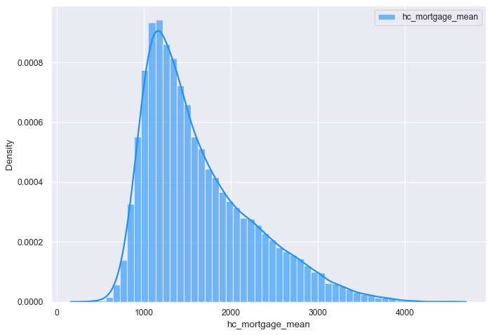

```python
# Plot
kwargs = dict(hist_kws={'alpha':.6}, kde_kws={'linewidth':2})

plt.figure(figsize=(10,7), dpi= 80)
sns.distplot(train_df.hc_mortgage_mean, color="dodgerblue", label="hc_mortgage_mean", **kwargs)
# sns.distplot(x2, color="orange", label="SUV", **kwargs)
# sns.distplot(x3, color="deeppink", label="minivan", **kwargs)
# plt.xlim(50,75)
plt.legend();
```

# Target Variable "hc_mortgage_mean" has a Positive Skew.

```python
from sklearn.linear_model import LinearRegression
```

```python
from sklearn.metrics import mean_squared_error, mean_absolute_error, r2_score, SCORERS
```

```python
lr = LinearRegression()
```

Adj r2 = 1-(1-R2)*(n-1)/(n-p-1)

```python
def adj_rsqrd(df, r2):
        # adjusted r2 using formula adj_r2 = 1 - (1- r2) * (n-1) / (n - k - 1)
    # k = number of predictors = data.shape[1] - 1
    adj_rsqrd = 1 - (1-r2)*(len(df) - 1) / (len(df) - (df.shape[1] - 1) - 1)
    return round(adj_rsqrd, 3)
```

```python
cat_cols_2_drop = ['UID', 'state', 'state_ab', 'city', 'place', 'type', 'primary', 'zip_code', 'area_code', 'lat', 'lng']
```

```python
train_df.drop(cat_cols_2_drop, axis=1, inplace=True)
```

```python
test_df.drop(cat_cols_2_drop, axis=1, inplace=True)
```

```python
train_df.drop(['COUNTYID', 'STATEID'], axis=1, inplace=True)
```

```python
test_y = test_df['hc_mortgage_mean']
```

```python
test_df.drop(['COUNTYID', 'STATEID', 'hc_mortgage_mean'], axis=1, inplace=True)
```

```python
print(train_df.shape, test_df.shape)
```

```
(26585, 65) (11355, 64)
```

```python
train_X = train_df.drop(columns=['hc_mortgage_mean'])
train_y = train_df['hc_mortgage_mean']
```

```python
lr.fit(train_X, train_y)
```

```
LinearRegression()
```

```python
predict_train = lr.predict(train_X)
predict_test = lr.predict(test_df)
```

```python
# model evaluation for testing set

mae = mean_absolute_error(test_y, predict_test)
mse = mean_squared_error(test_y, predict_test)
r2 = r2_score(test_y, predict_test)

print("The model performance for test set")
print("--------------------------------------")
print('MAE is {}'.format(round(mae, 3)))
print('MSE is {}'.format(round(mse, 3)))
print('RMSE is {}'.format(round(mse**(0.5), 3)))
print('R2 score is {}'.format(round(r2, 3)))

print('Adjusted R2 score is {}'.format(adj_rsqrd(test_df, r2)))
```

```
The model performance for test set
--------------------------------------
MAE is 43.675
MSE is 4673.486
RMSE is 68.363
R2 score is 0.988
Adjusted R2 score is 0.988
```

# Regression Model with all dependent numeric variables @ Country level is giving R SQUARED metric of 98.8%. So skipping state level Regression Model

```python
correlated_features = set()
correlation_matrix = train_df.drop('hc_mortgage_mean', axis=1).corr()

for i in range(len(correlation_matrix.columns)):
    for j in range(i):
        if abs(correlation_matrix.iloc[i, j]) > 0.8:
            colname = correlation_matrix.columns[i]
            correlated_features.add(colname)
```

```python
correlated_features
```

```
{'debt_cdf',
 'family_mean',
 'family_median',
 'family_sample_weight',
 'family_samples',
 'family_stdev',
 'female_age_mean',
 'female_age_median',
 'female_age_sample_weight',
 'female_age_samples',
 'female_pop',
 'hc_median',
 'hc_mortgage_samples',
 'hc_sample_weight',
 'hi_median',
 'hi_samples',
 'hi_stdev',
 'home_equity_cdf',
 'hs_degree_female',
 'hs_degree_male',
 'male_age_median',
 'male_age_sample_weight',
 'male_age_samples',
 'male_pop',
 'rent_gt_25',
 'rent_gt_30',
 'rent_gt_35',
 'rent_gt_40',
 'rent_gt_50',
 'rent_median',
 'rent_samples',
 'second_mortgage',
 'universe_samples',
 'used_samples'}
```

```python
corr_list = ['debt_cdf', 'family_mean', 'family_median', 'family_sample_weight', 'family_samples', 'family_stdev', 'female_age_mean', 'female_age_median',
                     'female_age_sample_weight', 'female_age_samples', 'female_pop', 'hc_median', 'hc_mortgage_samples', 'hc_sample_weight', 'hi_median',
                     'hi_samples', 'hi_stdev', 'home_equity_cdf', 'hs_degree_female', 'hs_degree_male', 'male_age_median', 'male_age_sample_weight',
                 'male_age_samples', 'male_pop', 'rent_gt_25', 'rent_gt_30', 'rent_gt_35', 'rent_gt_40', 'rent_gt_50', 'rent_median', 'rent_samples', 'second_mortgage', 'universe_samples', 'used_samples']
```

```python
train_df.drop(corr_list, axis=1, inplace=True)
```

```python
test_df.drop(corr_list, axis=1, inplace=True)
```

```python
print(train_df.shape, test_df.shape)
```

```
(26585, 31) (11355, 30)
```

# Dropped MultiCollinear variables and ran the Regression Model.

```python
train_df.head()
```

|  | ALand | AWater | pop | rent_mean | rent_stdev | rent_sample_weight | rent_gt_10 | rent_gt_15 | rent_gt_20 | hi_mean | hi_sample_weight | hc_mortgage_mean | hc_mortgage_median | hc_mortgage_stdev | hc_mortgage_sample_weight | hc_mean | hc_stdev | hc_samples | home_equity_second_mortgage | home_equity | debt | second_mortgage_cdf | hs_degree | male_age_mean | male_age_stdev | female_age_stdev | pct_own | married | married_snp | … |
| --- | --- | --- | --- | --- | --- | --- | --- | --- | --- | --- | --- | --- | --- | --- | --- | --- | --- | --- | --- | --- | --- | --- | --- | --- | --- | --- | --- | --- | --- | --- |
| 0 | 202183361.0 | 1699120 | 5230 | 769.38638 | 232.63967 | 272.34441 | 0.86761 | 0.79155 | 0.59155 | 63125.28406 | 1290.96240 | 1414.80295 | 1223.0 | 641.22898 | 377.83135 | 570.01530 | 270.11299 | 770.0 | 0.01588 | 0.08919 | 0.52963 | 0.43658 | 0.89288 | 42.48574 | 22.97306 | 22.51276 | 0.79046 | 0.57851 | 0.01882 | … |
| 1 | 1560828.0 | 100363 | 2633 | 804.87924 | 253.46747 | 312.58622 | 0.97410 | 0.93227 | 0.69920 | 41931.92593 | 838.74664 | 864.41390 | 784.0 | 482.27020 | 316.88320 | 351.98293 | 125.40457 | 229.0 | 0.02222 | 0.04274 | 0.60855 | 0.42174 | 0.90487 | 34.84728 | 20.37452 | 23.43353 | 0.52483 | 0.34886 | 0.01426 | … |
| 2 | 69561595.0 | 284193 | 6881 | 742.77365 | 323.39011 | 291.85520 | 0.95238 | 0.88624 | 0.79630 | 84942.68317 | 1155.20980 | 1506.06758 | 1361.0 | 731.89394 | 699.41354 | 556.45986 | 184.42175 | 538.0 | 0.00000 | 0.09512 | 0.73484 | 1.00000 | 0.94288 | 39.38154 | 22.89769 | 23.94119 | 0.85331 | 0.64745 | 0.02830 | … |
| 3 | 1105793.0 | 0 | 2700 | 803.42018 | 297.39258 | 259.30316 | 0.94693 | 0.87151 | 0.69832 | 48733.67116 | 928.32193 | 1175.28642 | 1101.0 | 428.98751 | 261.28471 | 288.04047 | 185.55887 | 392.0 | 0.01086 | 0.01086 | 0.52714 | 0.53057 | 0.91500 | 48.64749 | 23.05968 | 24.32015 | 0.65037 | 0.47257 | 0.02021 | … |
| 4 | 2554403.0 | 0 | 5637 | 938.56493 | 392.44096 | 1005.42886 | 0.99286 | 0.98247 | 0.91688 | 31834.15466 | 1548.67477 | 1192.58759 | 1125.0 | 327.49674 | 76.61052 | 443.68855 | 76.12674 | 124.0 | 0.05426 | 0.05426 | 0.51938 | 0.18332 | 1.00000 | 26.07533 | 11.84399 | 11.10484 | 0.13046 | 0.12356 | 0.00000 | … |

```python
train_X = train_df.drop(columns=['hc_mortgage_mean'])
train_y = train_df['hc_mortgage_mean']
```

```python
lr.fit(train_X, train_y)
```

```
LinearRegression()
```

```python
predict_train = lr.predict(train_X)
predict_test = lr.predict(test_df)
```

```python
# model evaluation for testing set

mae = mean_absolute_error(test_y, predict_test)
mse = mean_squared_error(test_y, predict_test)
r2 = r2_score(test_y, predict_test)

print("The model performance for test set")
print("--------------------------------------")
print('MAE is {}'.format(round(mae, 3)))
print('MSE is {}'.format(round(mse, 3)))
print('RMSE is {}'.format(round(mse**(0.5), 3)))
print('R2 score is {}'.format(round(r2, 3)))

print('Adjusted R2 score is {}'.format(adj_rsqrd(test_df, r2)))
```

```
The model performance for test set
--------------------------------------
MAE is 44.001
MSE is 4787.228
RMSE is 69.19
R2 score is 0.988
Adjusted R2 score is 0.988
```

```python
sorted(SCORERS.keys())
```

```
['accuracy',
 'adjusted_mutual_info_score',
 'adjusted_rand_score',
 'average_precision',
 'balanced_accuracy',
 'completeness_score',
 'explained_variance',
 'f1',
 'f1_macro',
 'f1_micro',
 'f1_samples',
 'f1_weighted',
 'fowlkes_mallows_score',
 'homogeneity_score',
 'jaccard',
 'jaccard_macro',
 'jaccard_micro',
 'jaccard_samples',
 'jaccard_weighted',
 'max_error',
 'mutual_info_score',
 'neg_brier_score',
 'neg_log_loss',
 'neg_mean_absolute_error',
 'neg_mean_gamma_deviance',
 'neg_mean_poisson_deviance',
 'neg_mean_squared_error',
 'neg_mean_squared_log_error',
 'neg_median_absolute_error',
 'neg_root_mean_squared_error',
 'normalized_mutual_info_score',
 'precision',
 'precision_macro',
 'precision_micro',
 'precision_samples',
 'precision_weighted',
 'r2',
 'recall',
 'recall_macro',
 'recall_micro',
 'recall_samples',
 'recall_weighted',
 'roc_auc',
 'roc_auc_ovo',
 'roc_auc_ovo_weighted',
 'roc_auc_ovr',
 'roc_auc_ovr_weighted',
 'v_measure_score']
```

# Let's Check how close our algorithm is predicting, by passing the inputs from our test set and compare them to the target values.

```python
import random
randomlist = []
for i in range(0,100):
    n = random.randint(1,len(test_df))
    randomlist.append(n)
print(randomlist)
```

```
[5017, 11339, 1838, 10169, 2484, 6124, 8393, 6118, 8550, 1959, 620, 2689, 10028, 6120, 5706, 996, 8517, 7407, 3330, 2886, 4942, 581, 10109, 8907, 4576, 10204, 10091, 204, 881, 9369, 11034, 6443, 6263, 7682, 5958, 8756, 9097, 10095, 6567, 3048, 2593, 7036, 3693, 6401, 3900, 2461, 5752, 2203, 6093, 25…
```

```python
pre_out = []
out = []

for i in randomlist:
    data_in = [list(test_df.iloc[i])]
    pre_data_out = lr.predict(data_in)
    data_out = test_y .iloc[i]

    print(i, pre_data_out, data_out)

    pre_out.append(pre_data_out)
    out.append(data_out)
```

```
5017 [980.98840874] 1020.71136
11339 [2011.05709176] 1944.7597399999997
1838 [1513.01157044] 1422.99748
10169 [1503.40027775] 1515.92725
2484 [1043.69550703] 1060.44108
6124 [1125.01101387] 1184.84169
8393 [1050.86060956] 1076.9534800000001
6118 [1463.88380511] 1509.65504
8550 [948.86439967] 936.08394
1959 [1023.01320305] 1061.20854
620 [1782.09191058] 1797.0207
2689 [975.20114401] 972.21377
10028 [2674.40093178] 2691.21003
6120 [1198.73905501] 1155.4516199999998
5706 [1421.80680715] 1437.37567
```

[output cut: 85 more lines]

```python
pre_out
```

```
[array([980.98840874]),
 array([2011.05709176]),
 array([1513.01157044]),
 array([1503.40027775]),
 array([1043.69550703]),
 array([1125.01101387]),
 array([1050.86060956]),
 array([1463.88380511]),
 array([948.86439967]),
 array([1023.01320305]),
 array([1782.09191058]),
 array([975.20114401]),
 array([2674.40093178]),
 array([1198.73905501]),
 array([1421.80680715]),
 array([2356.73740576]),
 array([906.14949766]),
 array([850.12201694]),
 array([1214.04574675]),
 array([1047.01167506]),
 array([1762.31028658]),
 array([1163.32610553]),
 array([1013.86570337]),
 array([1036.56970692]),
 array([1160.951397]),
 array([2571.74372218]),
 array([1246.66363903]),
 array([1778.82426126]),
 array([1383.01799477]),
 array([3089.08901299]),
 array([1265.6220323]),
 array([1231.2480032]),
 array([1441.44304353]),
 array([1244.69722159]),
 array([2373.17740923]),
 array([1097.25465308]),
 array([3694.84270759]),
 array([1623.34850522]),
 array([1618.42087368]),
 array([1988.93276008]),
```

[output cut: 45 more lines]

```
 array([1650.55827343]),
 array([1457.26319166]),
 array([1107.85906521]),
 array([2717.25495993]),
 array([1158.48035192]),
 array([1534.71616142]),
 array([1635.5267134]),
 array([1269.85854882]),
 array([2303.14517593]),
 array([2037.42887731]),
 array([1202.321266]),
 array([1391.39987093]),
 array([980.01645256]),
 array([1620.0276968]),
 array([974.56582613])]
```

```python
x = [2,3,5,9,1,0,2,3]

def my_min(sequence):
    """return the minimum element of sequence"""
    low = sequence[0] # need to start with some value
    for i in sequence:
        if i < low:
            low = i
    return low

print(my_min(x))
```

```
0
```

```python
x = [2,3,5,9,1,0,2,3]

def my_maxi(sequence):
    """return the minimum element of sequence"""
    maxi = sequence[0] # need to start with some value
    for i in sequence:
        if i > maxi:
            maxi = i
    return maxi

print(my_maxi(x))
```

```
9
```

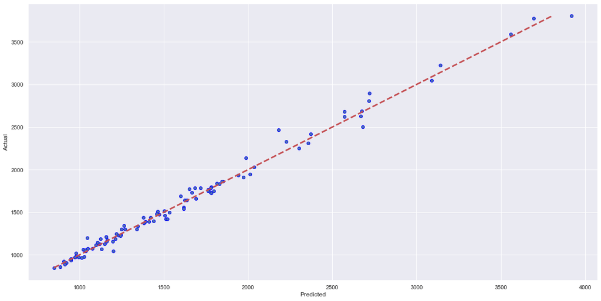

```python
fig, ax = plt.subplots(figsize=(20,10))
ax.scatter(pre_out, out, edgecolors=(0, 0, 1))
ax.plot([my_min(out), my_maxi(out)], [my_min(out), my_maxi(out)], 'r--', lw=3)
ax.set_xlabel('Predicted')
ax.set_ylabel('Actual')
plt.show()
```

```python
# model evaluation for testing set

mae = mean_absolute_error(test_y, predict_test)
mse = mean_squared_error(test_y, predict_test)
r2 = r2_score(test_y, predict_test)

print("The model performance for test set")
print("--------------------------------------")
print('MAE is {}'.format(round(mae, 3)))
print('MSE is {}'.format(round(mse, 3)))
print('RMSE is {}'.format(round(mse**(0.5), 3)))
print('R2 score is {}'.format(round(r2, 3)))

print('Adjusted R2 score is {}'.format(adj_rsqrd(test_df, r2)))
```

```
The model performance for test set
--------------------------------------
MAE is 44.001
MSE is 4787.228
RMSE is 69.19
R2 score is 0.988
Adjusted R2 score is 0.988
```

# We have achieved an adjusted R Squared value of 98.8% which is pretty close to 1, indicating our selected "Independent Variables" are highly correlated to our "Dependent Variable" and our model is able to predict very accurately.

# By : Abdullah Alwabel